# Nigeria Subnational BPI 2024

## Rescale Zinc deficiency

- Percentage of population at risk of inadequate intake of zinc. This is now available at the subnational level from the 2021 NFCMS as *womens’s prevalence of inadequacy of zinc intakes*. A further indicator is also available: *prevalence of women of reproductive age with zinc deficiency* and *prevalence of children with zinc deficiency* These are only available at the geopolitical zone level in Nigeria, but are potentially an improvement on both the global and 2018 subnational indicators

#### Zinc deficiency women of reproductive age (NFCMS, 2021)

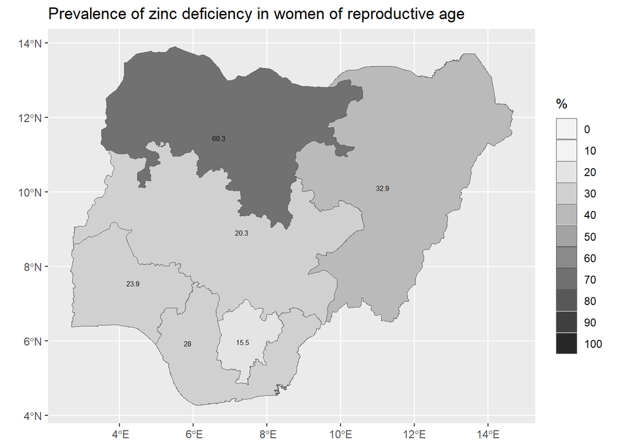

```r
ggplot(vect_gpz_geo_NFCMS) +
  geom_spatvector(aes(fill = WRA_def_zinc_pc_252)) +
  geom_spatvector_text(aes(label = WRA_def_zinc_pc_252), size = 2) +
  scale_fill_stepsn(
    n.breaks = 10,
    limits = c(0, 100),
    colours = hcl.colors(palette = "Grays", 10, rev = T),
    guide = "legend",
    na.value = "pink",
    labels = scales::comma
  ) +
  labs(title = "Prevalence of zinc deficiency in women of reproductive age", fill = "%") +
  theme(
    plot.title = element_markdown(),
    legend.title = element_markdown(),
    axis.title = element_blank()
  )
```

```r
df_NFCMS_zinc_deficiency_WRA <- as.data.frame(vect_gpz_geo_NFCMS)

df_NFCMS_zinc_deficiency_WRA_normalised <- as.data.frame(lapply(select(df_NFCMS_zinc_deficiency_WRA, WRA_def_zinc_pc_252 ), minMax))

head(df_NFCMS_zinc_deficiency_WRA_normalised)
```

WRA_def_zinc_pc_252 1 0.1071429 2 0.3883929 3 1.0000000 4 0.0000000 5 0.2790179 6 0.1875000

```r
df_NFCMS_zinc_deficiency_WRA_rescale <- bind_cols(select(df_NFCMS_zinc_deficiency_WRA, geopolitical_zone), df_NFCMS_zinc_deficiency_WRA_normalised)
```

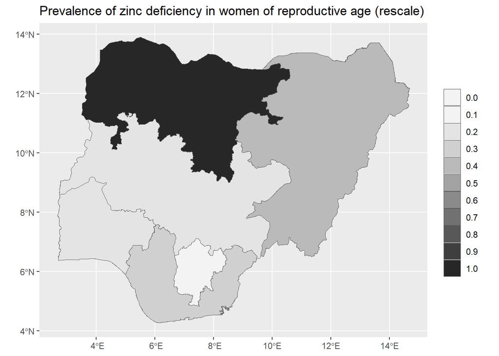

```r
vect_state_geo_NFCMS_zinc_deficiency_WRA_rescale <- dplyr::left_join(vect_gpz_geo, df_NFCMS_zinc_deficiency_WRA_rescale, by = "geopolitical_zone")

ggplot(vect_state_geo_NFCMS_zinc_deficiency_WRA_rescale) +
  geom_spatvector(aes(fill = WRA_def_zinc_pc_252)) +
  scale_fill_stepsn(
    n.breaks = 10,
    limits = c(0, 1),
    colours = hcl.colors(palette = "Grays", 10, rev = T),
    guide = "legend",
    na.value = "pink",
    labels = scales::comma
  ) +
  labs(title = "Prevalence of zinc deficiency in women of reproductive age (rescale)", fill = "") +
  theme(
    plot.title = element_markdown(),
    legend.title = element_markdown(),
    axis.title = element_blank()
  )
```

#### Zinc deficiency in children (NFCMS, 2021)

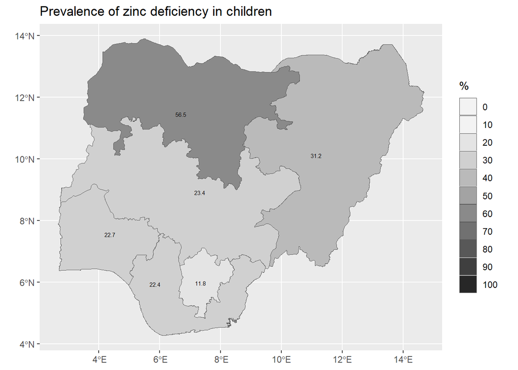

```r
ggplot(vect_gpz_geo_NFCMS) +
  geom_spatvector(aes(fill = CH_def_zinc_pc_238)) +
  geom_spatvector_text(aes(label = CH_def_zinc_pc_238), size = 2) +
  scale_fill_stepsn(
    n.breaks = 10,
    limits = c(0, 100),
    colours = hcl.colors(palette = "Grays", 10, rev = T),
    guide = "legend",
    na.value = "pink",
    labels = scales::comma
  ) +
  labs(title = "Prevalence of zinc deficiency in children", fill = "%") +
  theme(
    plot.title = element_markdown(),
    legend.title = element_markdown(),
    axis.title = element_blank()
  )
```

```r
df_NFCMS_zinc_deficiency_CH <- as.data.frame(vect_gpz_geo_NFCMS)

df_NFCMS_zinc_deficiency_CH_normalised <- as.data.frame(lapply(select(df_NFCMS_zinc_deficiency_CH, CH_def_zinc_pc_238 ), minMax))

head(df_NFCMS_zinc_deficiency_CH_normalised)
```

CH_def_zinc_pc_238 1 0.2595078 2 0.4340045 3 1.0000000 4 0.0000000 5 0.2371365 6 0.2438479

```r
df_NFCMS_zinc_deficiency_CH_rescale <- bind_cols(select(df_NFCMS_zinc_deficiency_CH, geopolitical_zone), df_NFCMS_zinc_deficiency_CH_normalised)
```

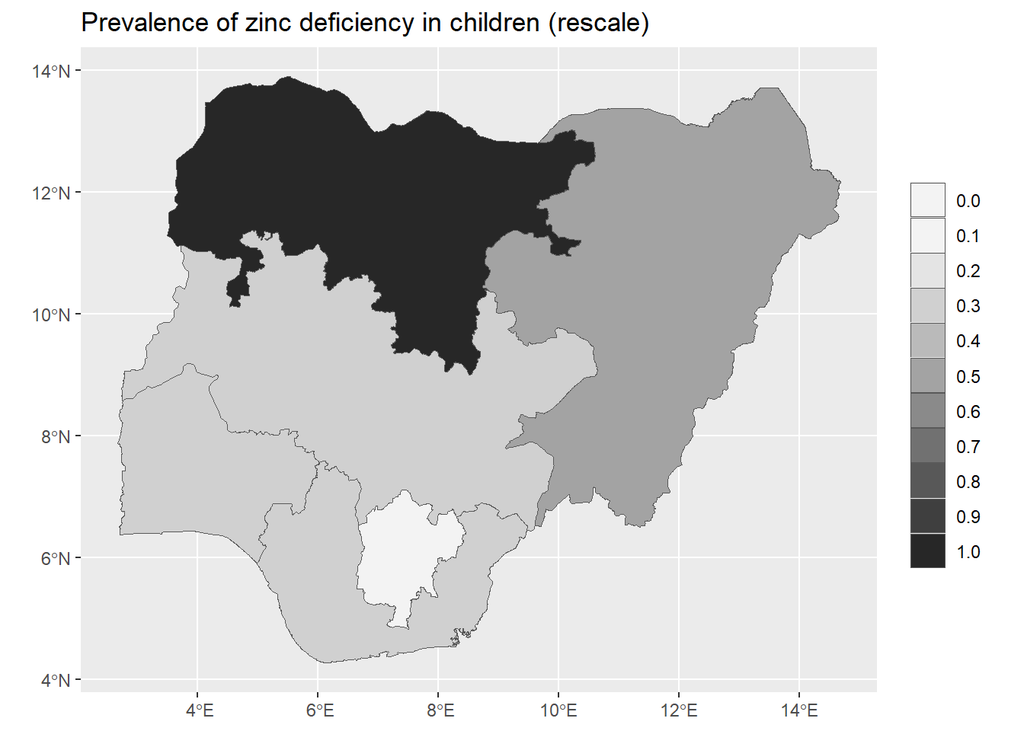

```r
vect_state_geo_NFCMS_zinc_deficiency_CH_rescale <- dplyr::left_join(vect_gpz_geo, df_NFCMS_zinc_deficiency_CH_rescale, by = "geopolitical_zone")

ggplot(vect_state_geo_NFCMS_zinc_deficiency_CH_rescale) +
  geom_spatvector(aes(fill = CH_def_zinc_pc_238)) +
  scale_fill_stepsn(
    n.breaks = 10,
    limits = c(0, 1),
    colours = hcl.colors(palette = "Grays", 10, rev = T),
    guide = "legend",
    na.value = "pink",
    labels = scales::comma
  ) +
  labs(title = "Prevalence of zinc deficiency in children (rescale)", fill = "") +
  theme(
    plot.title = element_markdown(),
    legend.title = element_markdown(),
    axis.title = element_blank()
  )
```

### Zinc deficient intake

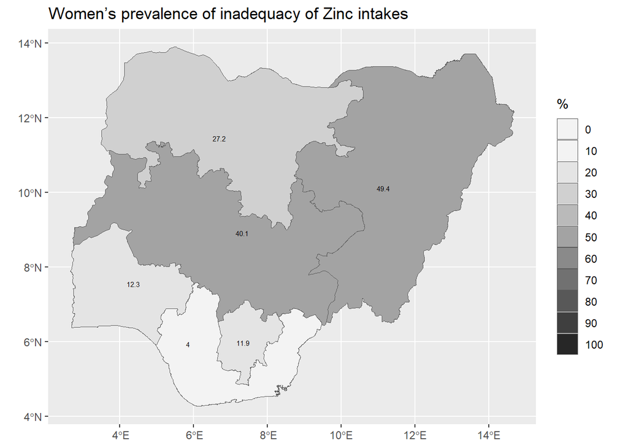

```r
ggplot(vect_gpz_geo_NFCMS_consumption) +
  geom_spatvector(aes(fill = ZINC_IN_DEF_W_76)) +
  geom_spatvector_text(aes(label = ZINC_IN_DEF_W_76), size = 2) +
  scale_fill_stepsn(
    n.breaks = 10,
    limits = c(0, 100),
    colours = hcl.colors(palette = "Grays", 10, rev = T),
    guide = "legend",
    na.value = "pink",
    labels = scales::comma
  ) +
  labs(title = "Women's prevalence of inadequacy of Zinc intakes", fill = "%") +
  theme(
    plot.title = element_markdown(),
    legend.title = element_markdown(),
    axis.title = element_blank()
  )
```

```r
df_NFCMS_zinc_intake_WRA <- as.data.frame(vect_gpz_geo_NFCMS_consumption)

df_NFCMS_zinc_intake_WRA_normalised <- as.data.frame(lapply(select(df_NFCMS_zinc_intake_WRA, ZINC_IN_DEF_W_76 ), minMax))

head(df_NFCMS_zinc_intake_WRA_normalised)
```

ZINC_IN_DEF_W_76 1 0.7951542 2 1.0000000 3 0.5110132 4 0.1740088 5 0.0000000 6 0.1828194

```r
df_NFCMS_zinc_intake_WRA_rescale <- bind_cols(select(df_NFCMS_zinc_intake_WRA, geopolitical_zone), df_NFCMS_zinc_intake_WRA_normalised)
```

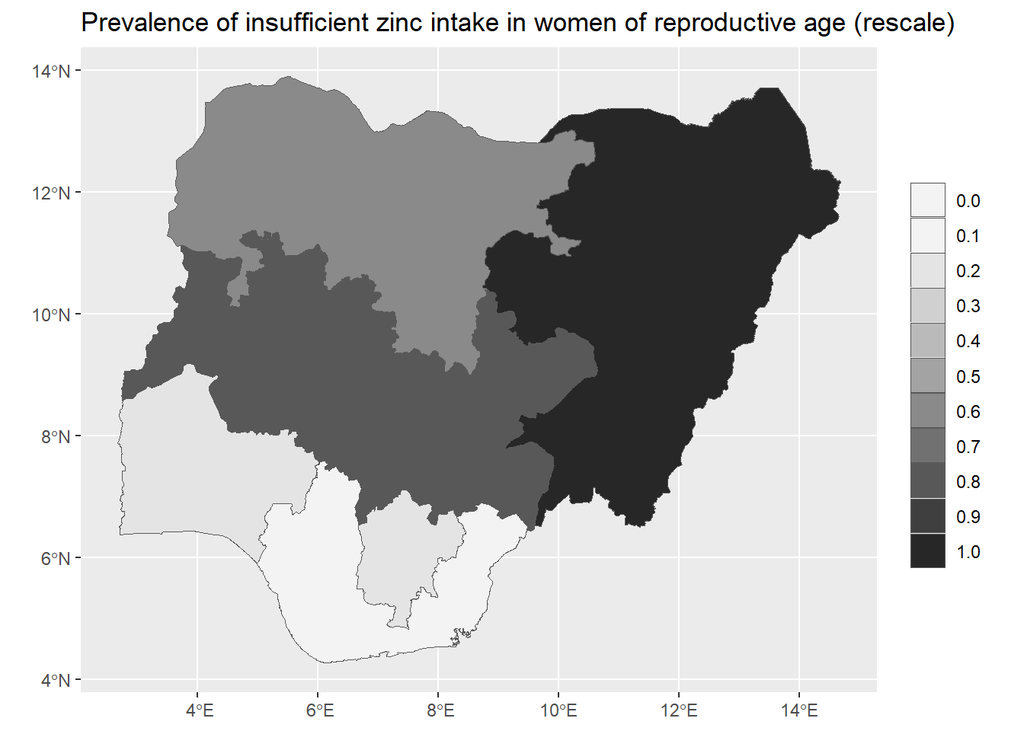

```r
vect_state_geo_NFCMS_zinc_intake_WRA_rescale <- dplyr::left_join(vect_gpz_geo, df_NFCMS_zinc_intake_WRA_rescale, by = "geopolitical_zone")

ggplot(vect_state_geo_NFCMS_zinc_intake_WRA_rescale) +
  geom_spatvector(aes(fill = ZINC_IN_DEF_W_76)) +
  scale_fill_stepsn(
    n.breaks = 10,
    limits = c(0, 1),
    colours = hcl.colors(palette = "Grays", 10, rev = T),
    guide = "legend",
    na.value = "pink",
    labels = scales::comma
  ) +
  labs(title = "Prevalence of insufficient zinc intake in women of reproductive age (rescale)", fill = "") +
  theme(
    plot.title = element_markdown(),
    legend.title = element_markdown(),
    axis.title = element_blank()
  )
```

## Rescale prevalence of stunting among children age 6-59 months

```r
df_NDHS_stunting_state <- read.csv("E:/repos/Nigeria_Biofortification_Atlas/tab_data/Nigeria_NDHS2024_stunting_GBD_join.csv")


df_NDHS_stunting_state$state <- as.factor(df_NDHS_stunting_state$state)

cat(paste(levels(df_NDHS_stunting_state$state), "; ")) # Check levels
```

Abia ; Adamawa ; Akwa Ibom ; Anambra ; Bauchi ; Bayelsa ; Benue ; Borno ; Cross River ; Delta ; Ebonyi ; Edo ; Ekiti ; Enugu ; Federal Capital Territory ; Gombe ; Imo ; Jigawa ; Kaduna ; Kano ; Katsina ; Kebbi ; Kogi ; Kwara ; Lagos ; Nasarawa ; Niger ; Ogun ; Ondo ; Osun ; Oyo ; Plateau ; Rivers ; Sokoto ; Taraba ; Yobe ; Zamfara ;

```r
vect_state_geo_NDHS_stunting <- dplyr::left_join(vect_state_geo, df_NDHS_stunting_state, by = c("adm1_ref_name"  = "state"))
vect_state_geo_NDHS_stunting |> as.data.frame() |>
  DT::datatable(
    rownames = F,
    filter = "bottom",
    selection = list(mode = "none"),
    editable = FALSE,
    options = list(
      digits = 0,
      scrollX = TRUE,
      scrollCollapse = TRUE,
      autoWidth = TRUE,
      fixedColumns = list(leftColumns = 2),
      lengthMenu = c(15, 40),
      pageLength = 15
    ))
```

| id | area_sqkm | valid_on | valid_to | adm0_pcode | adm0_name3 | adm1_ref_name | adm0_name2 | adm0_name | adm1_pcode | adm0_name1 | lang1 | lang3 | adm1_name3 | adm1_name2 | version | lang | adm1_name1 | adm1_name | lang2 | center_lat | center_lon | country | ihme_location_name | ihme_location_id | iso_3166_2 | stunting_ndhs2024_pct |
| --- | --- | --- | --- | --- | --- | --- | --- | --- | --- | --- | --- | --- | --- | --- | --- | --- | --- | --- | --- | --- | --- | --- | --- | --- | --- | --- |
|  | 4859.5031378 | 2019-04-17T05:00:00Z |  | NG |  | Abia |  | Nigeria | NG001 |  |  |  |  |  | v01 | en |  | Abia |  | 5.4318197 | 7.4883421 | Nigeria | Abia |  | NG-AB | 20 |
|  | 37821.6738411 | 2019-04-17T05:00:00Z |  | NG |  | Adamawa |  | Nigeria | NG002 |  |  |  |  |  | v01 | en |  | Adamawa |  | 9.1626472 | 12.2915621 | Nigeria | Adamawa |  | NG-AD | 49 |
|  | 6739.3559919 | 2019-04-17T05:00:00Z |  | NG |  | Akwa Ibom |  | Nigeria | NG003 |  |  |  |  |  | v01 | en |  | Akwa Ibom |  | 4.99047 | 7.7955686 | Nigeria | Akwa Ibom |  | NG-AK | 24 |
|  | 4805.5194821 | 2019-04-17T05:00:00Z |  | NG |  | Anambra |  | Nigeria | NG004 |  |  |  |  |  | v01 | en |  | Anambra |  | 6.2485292 | 6.9378734 | Nigeria | Anambra |  | NG-AN | 13 |
|  | 48516.7133317 | 2019-04-17T05:00:00Z |  | NG |  | Bauchi |  | Nigeria | NG005 |  |  |  |  |  | v01 | en |  | Bauchi |  | 10.9978941 | 9.3258168 | Nigeria | Bauchi |  | NG-BA | 62 |
|  | 9529.0165288 | 2019-04-17T05:00:00Z |  | NG |  | Bayelsa |  | Nigeria | NG006 |  |  |  |  |  | v01 | en |  | Bayelsa |  | 4.8268244 | 5.951137 | Nigeria | Bayelsa |  | NG-BY | 28 |
|  | 31483.3370793 | 2019-04-17T05:00:00Z |  | NG |  | Benue |  | Nigeria | NG007 |  |  |  |  |  | v01 | en |  | Benue |  | 7.3009378 | 8.8123949 | Nigeria | Benue |  | NG-BE | 25 |
|  | 72156.5967627 | 2019-04-17T05:00:00Z |  | NG |  | Borno |  | Nigeria | NG008 |  |  |  |  |  | v01 | en |  | Borno |  | 11.8700727 | 13.4276227 | Nigeria | Borno |  | NG-BO | 41 |
|  | 20954.9259246 | 2019-04-17T05:00:00Z |  | NG |  | Cross River |  | Nigeria | NG009 |  |  |  |  |  | v01 | en |  | Cross River |  | 5.7913258 | 8.4034469 | Nigeria | Cross River |  | NG-CR | 21 |
|  | 17076.8408191 | 2019-04-17T05:00:00Z |  | NG |  | Delta |  | Nigeria | NG010 |  |  |  |  |  | v01 | en |  | Delta |  | 5.756556 | 5.4996657 | Nigeria | Delta |  | NG-DE | 20 |

[output cut: 27 more lines]

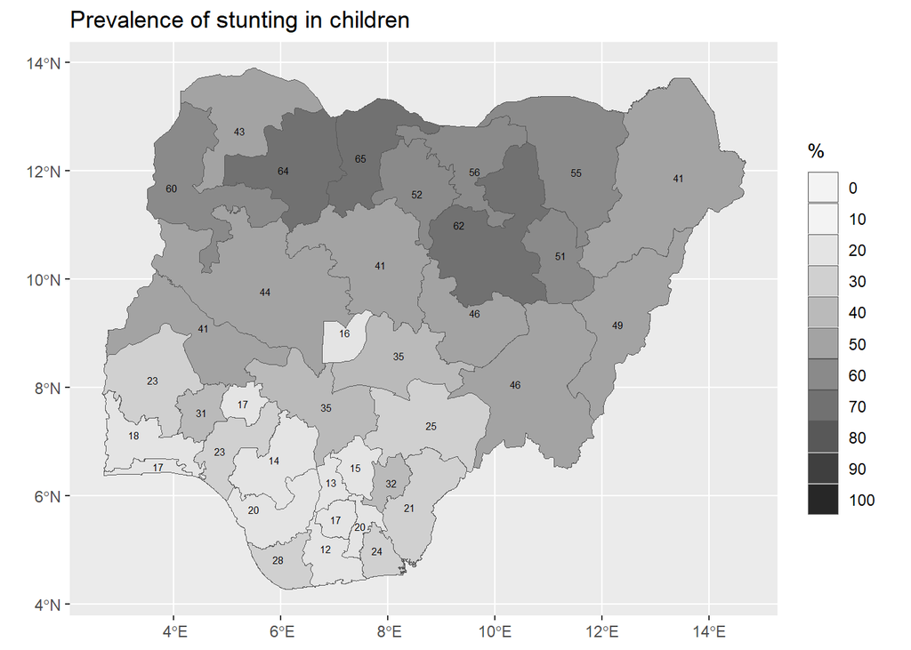

```r
ggplot(vect_state_geo_NDHS_stunting) +
  geom_spatvector(aes(fill = stunting_ndhs2024_pct)) +
  geom_spatvector_text(aes(label = stunting_ndhs2024_pct), size = 2) +
  scale_fill_stepsn(
    n.breaks = 10,
    limits = c(0, 100),
    colours = hcl.colors(palette = "Grays", 10, rev = T),
    guide = "legend",
    na.value = "pink",
    labels = scales::comma
  ) +
  labs(title = "Prevalence of stunting in children", fill = "%") +
  theme(
    plot.title = element_markdown(),
    legend.title = element_markdown(),
    axis.title = element_blank()
  )
```

```r
df_NDHS_stunting_CH_normalised <- as.data.frame(lapply(select(df_NDHS_stunting_state, -country, -state, -ihme_location_name, -ihme_location_id, -iso_3166_2), minMax))

head(df_NDHS_stunting_CH_normalised)
```

stunting_ndhs2024_pct 1 0.15094340 2 0.69811321 3 0.22641509 4 0.01886792 5 0.94339623 6 0.30188679

```r
df_NDHS_stunting_CH_rescale <- bind_cols(select(df_NDHS_stunting_state, state), df_NDHS_stunting_CH_normalised)
```

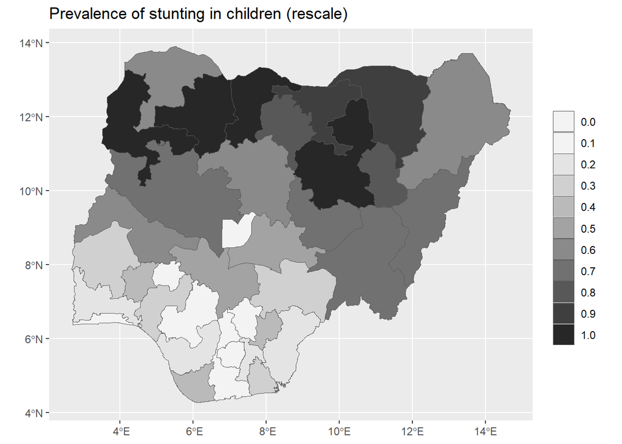

```r
vect_state_geo_NDHS_stunting_rescale <- dplyr::left_join(vect_state_geo, df_NDHS_stunting_CH_rescale, by = c("adm1_ref_name"  = "state"))

ggplot(vect_state_geo_NDHS_stunting_rescale) +
  geom_spatvector(aes(fill = stunting_ndhs2024_pct)) +
  scale_fill_stepsn(
    n.breaks = 10,
    limits = c(0, 1),
    colours = hcl.colors(palette = "Grays", 10, rev = T),
    guide = "legend",
    na.value = "pink",
    labels = scales::comma
  ) +
  labs(title = "Prevalence of stunting in children (rescale)", fill = "") +
  theme(
    plot.title = element_markdown(),
    legend.title = element_markdown(),
    axis.title = element_blank()
  )
```

## Rescale age-standardized DALYs lost to dietary IDA

- Age-standardized DALYs lost per 100,000 inhabitants to IDA. The IMHE GBD database includes Age standardised DALYs Dietary iron Deficiency - a slightly different indicator, which focuses on the dietary component of anaemia, but is available at the state level

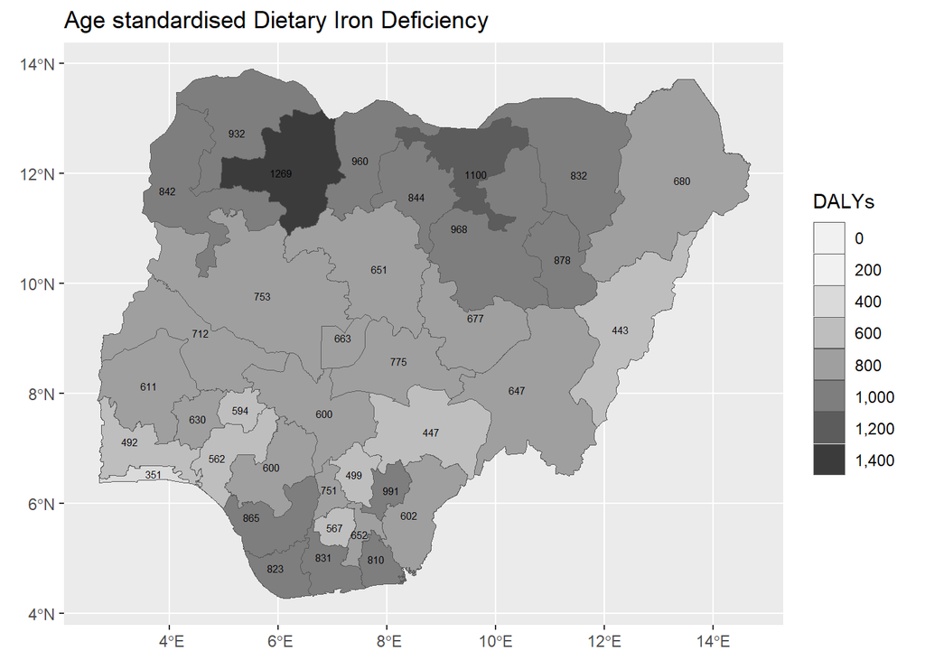

```r
ggplot(tidyterra::filter(vect_state_geo_IHME, cause_name == "Dietary iron deficiency")) +
  geom_spatvector(aes(fill = val)) +
  geom_spatvector_text(aes(label = round(val)), size = 2) +
  scale_fill_stepsn(
    n.breaks = 10,
    limits = c(0, 1500),
    colours = hcl.colors(palette = "Grays", 10, rev = T),
    guide = "legend",
    na.value = "pink",
    labels = scales::comma
  ) +
  labs(title = "Age standardised Dietary Iron Deficiency", fill = "DALYs") +
  theme(
    plot.title = element_markdown(),
    legend.title = element_markdown(),
    axis.title = element_blank()
  )
```

```r
df_IHME_iron_DALYs <- as.data.frame(tidyterra::filter(vect_state_geo_IHME, cause_name == "Dietary iron deficiency")) |> select(adm1_ref_name, val)

df_IHME_iron_DALYs_normalised <- as.data.frame(lapply(select(df_IHME_iron_DALYs, -adm1_ref_name), minMax))
head(df_IHME_iron_DALYs_normalised)
```

```
    val
```

1 0.3279176 2 0.1001353 3 0.5002898 4 0.4352995 5 0.6716978 6 0.5138968

```r
df_IHME_iron_DALYs_rescale <- bind_cols(select(df_IHME_iron_DALYs, adm1_ref_name), df_IHME_iron_DALYs_normalised)
```

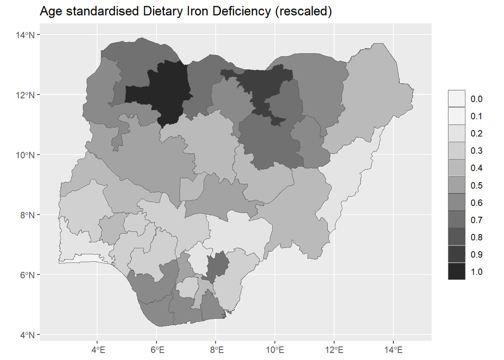

```r
vect_state_geo_IHME_iron_DALYs_rescale <- dplyr::left_join(vect_state_geo, df_IHME_iron_DALYs_rescale, by = "adm1_ref_name")

ggplot(vect_state_geo_IHME_iron_DALYs_rescale) +
  geom_spatvector(aes(fill = val)) +
  scale_fill_stepsn(
    n.breaks = 10,
    limits = c(0, 1),
    colours = hcl.colors(palette = "Grays", 10, rev = T),
    guide = "legend",
    na.value = "pink",
    labels = scales::comma
  ) +
  labs(title = "Age standardised Dietary Iron Deficiency (rescaled)", fill = "") +
  theme(
    plot.title = element_markdown(),
    legend.title = element_markdown(),
    axis.title = element_blank()
  )
```

## Rescale NDHS combined anaemia

- Proportion of preschool-age children with Hb < 110 g/l - the NFCMS includes Iron deficiency in children defined as serum ferritin concentration <15 µg/L corrected for inflammation. Both the NFCMS and NDHS include anaemia for pre-school children - for the NDHS at the state level, and for NFCMS at the zone level. The definition of any anaemia in the NDHS is is when haemoglobin level is <12.0 g/dl. A closer level of Haemoglobin to the global BPI is for moderate and severe anaemia, which combined have an upper limit of 11 g/dl.

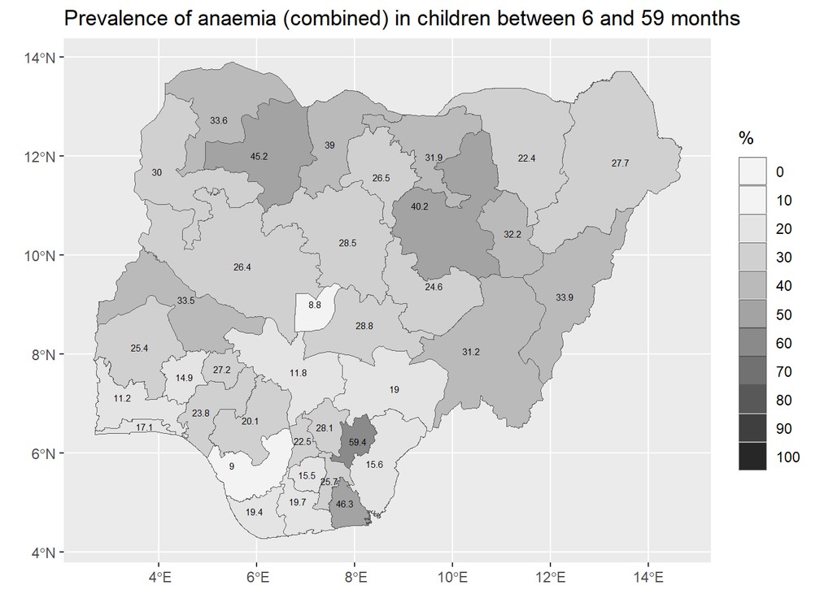

```r
vect_state_geo_NDHS$CH_anaemia_comb <- (vect_state_geo_NDHS$CH_anaemia_mod + vect_state_geo_NDHS$CH_anaemia_sev)


ggplot(vect_state_geo_NDHS) +
  geom_spatvector(aes(fill = CH_anaemia_comb)) +
  geom_spatvector_text(aes(label = CH_anaemia_comb), size = 2) +
  scale_fill_stepsn(
    n.breaks = 10,
    limits = c(0, 100),
    colours = hcl.colors(palette = "Grays", 10, rev = T),
    guide = "legend",
    na.value = "pink",
    labels = scales::comma
  ) +
  labs(title = "Prevalence of anaemia (combined) in children between 6 and 59 months", fill = "%") +
  theme(
    plot.title = element_markdown(),
    legend.title = element_markdown(),
    axis.title = element_blank()
  )
```

```r
df_NDHS_anaemia_combined_CH <- select(as.data.frame(vect_state_geo_NDHS), adm1_ref_name, CH_anaemia_comb)

df_NDHS_anaemia_combined_CH_normalised <- as.data.frame(lapply(select(df_NDHS_anaemia_combined_CH, -adm1_ref_name), minMax))
head(df_NDHS_anaemia_combined_CH_normalised)
```

CH_anaemia_comb 1 0.3339921 2 0.4960474 3 0.7411067 4 0.2707510 5 0.6205534 6 0.2094862

```r
df_NDHS_anaemia_combined_CH_rescale <- bind_cols(select(df_NDHS_anaemia_combined_CH, adm1_ref_name), df_NDHS_anaemia_combined_CH_normalised)
```

### Join back to States dataset

```r
vect_state_geo_NDHS_anaemia_combined_CH_rescale <- dplyr::left_join(vect_state_geo, df_NDHS_anaemia_combined_CH_rescale, by = "adm1_ref_name")
```

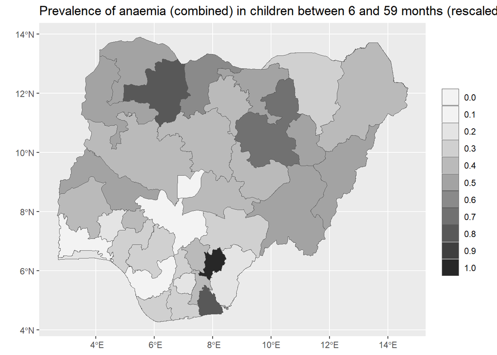

```r
ggplot(vect_state_geo_NDHS_anaemia_combined_CH_rescale) +
  geom_spatvector(aes(fill = CH_anaemia_comb)) +
  scale_fill_stepsn(
    n.breaks = 10,
    limits = c(0, 1),
    colours = hcl.colors(palette = "Grays", 10, rev = T),
    guide = "legend",
    na.value = "pink",
    labels = scales::comma
  ) +
  labs(title = "Prevalence of anaemia (combined) in children between 6 and 59 months (rescaled)", fill = "") +
  theme(
    plot.title = element_markdown(),
    legend.title = element_markdown(),
    axis.title = element_blank()
  )
```

## Compute the BPI components

### Production Index

$$PI = {0.5 * PCAH^r}+ {0.5 * SHA^r} \tag{3}$$
Where:

- $PI$ is the Production Index for a specific crop
- $PCAH^r$ is the rescaled Per capita area harvested
- $SHA^r$ is the rescaled share of the cropland

#### Plantain/Banana Production Index

```r
df_plantain_banana_PI <- left_join(
  select(df_crop_area_share_rescale, adm1_ref_name, plantain_banana_share_2024),
  select(df_crop_area_pc_rescale, adm1_ref_name, plantain_banana_pc_2024),
  by = "adm1_ref_name"
) |> mutate(plantain_banana_PI = ((plantain_banana_share_2024 * 0.5) + (plantain_banana_pc_2024 * 0.5)))

median_plantain_banana_PI <- median(df_plantain_banana_PI$plantain_banana_PI)
cat(paste("Median Plantain/Banana PI = ", median_plantain_banana_PI))
```

Median Plantain/Banana PI = 0

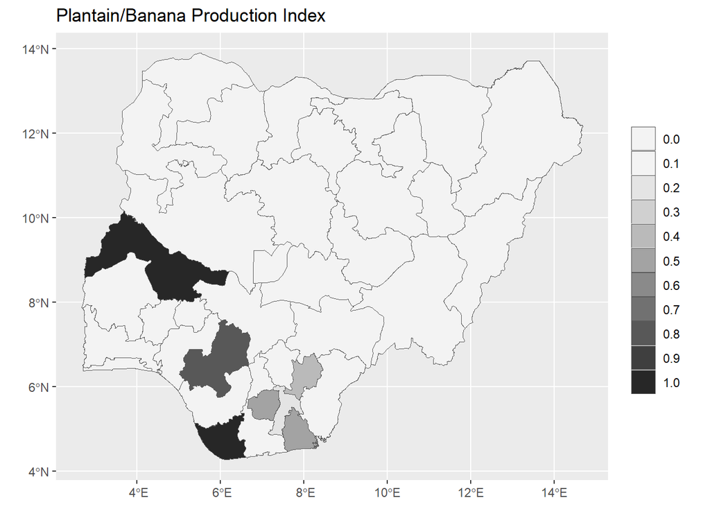

```r
vect_state_geo_plantain_banana_PI <- dplyr::left_join(vect_state_geo, df_plantain_banana_PI, by = "adm1_ref_name")

ggplot(vect_state_geo_plantain_banana_PI) +
  geom_spatvector(aes(fill = plantain_banana_PI)) +
  scale_fill_stepsn(
    n.breaks = 10,
    limits = c(0, 1),
    colours = hcl.colors(palette = "Grays", 10, rev = T),
    guide = "legend",
    na.value = "pink",
    labels = scales::comma
  ) +
  labs(title = "Plantain/Banana Production Index", fill = "") +
  theme(
    plot.title = element_markdown(),
    legend.title = element_markdown(),
    axis.title = element_blank()
  )
```

#### Cassava Production Index

```r
df_cassava_PI <- left_join(
  select(df_crop_area_share_rescale, adm1_ref_name, cassava_share_2022),
  select(df_crop_area_pc_rescale, adm1_ref_name, cassava_pc_2022),
  by = "adm1_ref_name"
) |> mutate(cassava_PI = ((cassava_share_2022 * 0.5) + (cassava_pc_2022 * 0.5)))

median_cassava_PI <- median(df_cassava_PI$cassava_PI)
cat(paste("Median Cassava PI = ", median_cassava_PI))
```

Median Cassava PI = 0.245862256788534

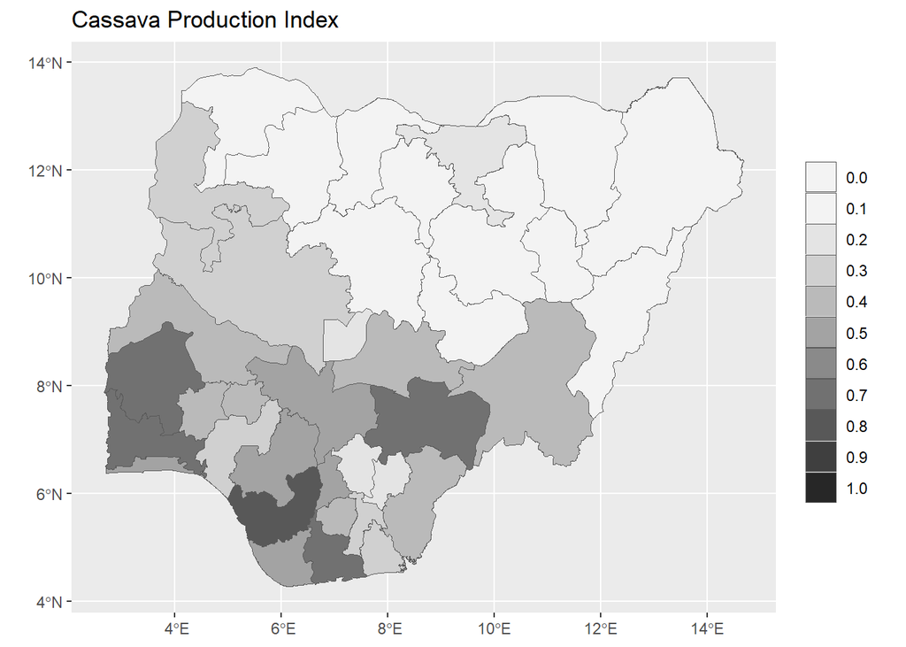

```r
vect_state_geo_cassava_PI <- dplyr::left_join(vect_state_geo, df_cassava_PI, by = "adm1_ref_name")

ggplot(vect_state_geo_cassava_PI) +
  geom_spatvector(aes(fill = cassava_PI)) +
  scale_fill_stepsn(
    n.breaks = 10,
    limits = c(0, 1),
    colours = hcl.colors(palette = "Grays", 10, rev = T),
    guide = "legend",
    na.value = "pink",
    labels = scales::comma
  ) +
  labs(title = "Cassava Production Index", fill = "") +
  theme(
    plot.title = element_markdown(),
    legend.title = element_markdown(),
    axis.title = element_blank()
  )
```

#### Cowpea Production Index

```r
df_cowpea_PI <- left_join(
  select(df_crop_area_share_rescale, adm1_ref_name, cowpea_share_2022),
  select(df_crop_area_pc_rescale, adm1_ref_name, cowpea_pc_2022),
  by = "adm1_ref_name"
) |> mutate(cowpea_PI = ((cowpea_share_2022 * 0.5) + (cowpea_pc_2022 * 0.5)))

median_cowpea_PI <- median(df_cowpea_PI$cowpea_PI)
cat(paste("Median Cowpea PI = ", median_cassava_PI))
```

Median Cowpea PI = 0.245862256788534

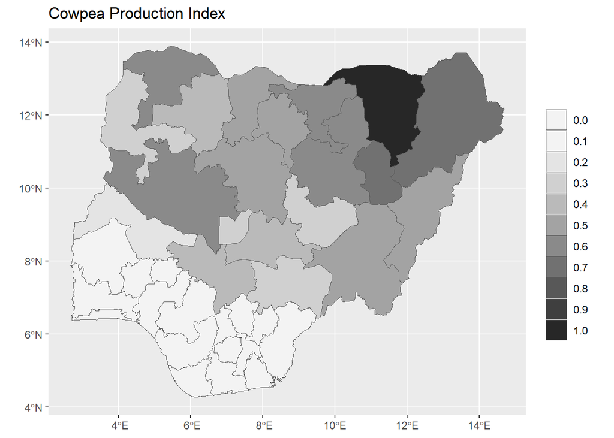

```r
vect_state_geo_cowpea_PI <- dplyr::left_join(vect_state_geo, df_cowpea_PI, by = "adm1_ref_name")

ggplot(vect_state_geo_cowpea_PI) +
  geom_spatvector(aes(fill = cowpea_PI)) +
  scale_fill_stepsn(
    n.breaks = 10,
    limits = c(0, 1),
    colours = hcl.colors(palette = "Grays", 10, rev = T),
    guide = "legend",
    na.value = "pink",
    labels = scales::comma
  ) +
  labs(title = "Cowpea Production Index", fill = "") +
  theme(
    plot.title = element_markdown(),
    legend.title = element_markdown(),
    axis.title = element_blank()
  )
```

#### Maize Production Index

```r
df_maize_PI <- left_join(
  select(df_crop_area_share_rescale, adm1_ref_name, maize_share_2022),
  select(df_crop_area_pc_rescale, adm1_ref_name, maize_pc_2022),
  by = "adm1_ref_name"
) |> mutate(maize_PI = ((maize_share_2022 * 0.5) + (maize_pc_2022 * 0.5)))

median_maize_PI <- median(df_maize_PI$maize_PI)
cat(paste("Median Maize PI = ", median_maize_PI))
```

Median Maize PI = 0.286679092308919

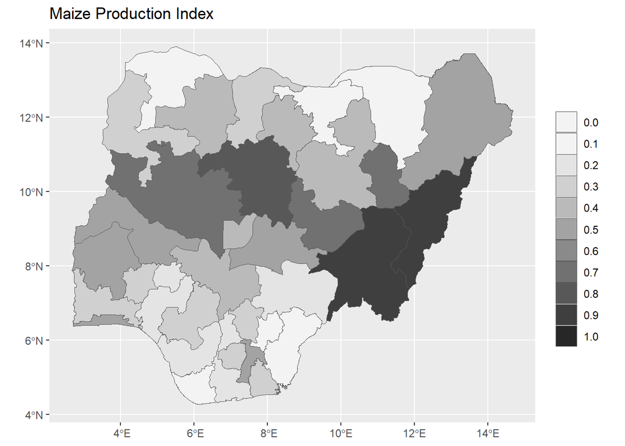

```r
vect_state_geo_maize_PI <- dplyr::left_join(vect_state_geo, df_maize_PI, by = "adm1_ref_name")

ggplot(vect_state_geo_maize_PI) +
  geom_spatvector(aes(fill = maize_PI)) +
  scale_fill_stepsn(
    n.breaks = 10,
    limits = c(0, 1),
    colours = hcl.colors(palette = "Grays", 10, rev = T),
    guide = "legend",
    na.value = "pink",
    labels = scales::comma
  ) +
  labs(title = "Maize Production Index", fill = "") +
  theme(
    plot.title = element_markdown(),
    legend.title = element_markdown(),
    axis.title = element_blank()
  )
```

#### Rice Production Index

```r
df_rice_PI <- left_join(
  select(df_crop_area_share_rescale, adm1_ref_name, rice_share_2024),
  select(df_crop_area_pc_rescale, adm1_ref_name, rice_pc_2024),
  by = "adm1_ref_name"
) |> mutate(rice_PI = ((rice_share_2024 * 0.5) + (rice_pc_2024 * 0.5)))

median_rice_PI <- median(df_rice_PI$rice_PI)
cat(paste("Median Rice PI = ", median_rice_PI))
```

Median Rice PI = 0.376134749425777

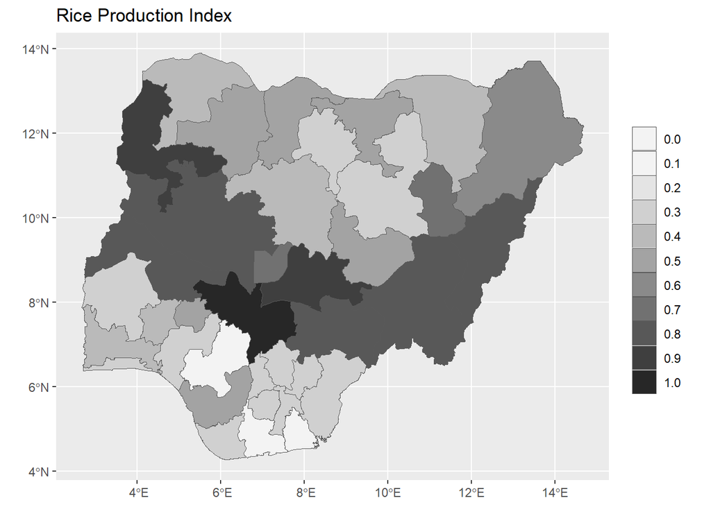

```r
vect_state_geo_rice_PI <- dplyr::left_join(vect_state_geo, df_rice_PI, by = "adm1_ref_name")

ggplot(vect_state_geo_rice_PI) +
  geom_spatvector(aes(fill = rice_PI)) +
  scale_fill_stepsn(
    n.breaks = 10,
    limits = c(0, 1),
    colours = hcl.colors(palette = "Grays", 10, rev = T),
    guide = "legend",
    na.value = "pink",
    labels = scales::comma
  ) +
  labs(title = "Rice Production Index", fill = "") +
  theme(
    plot.title = element_markdown(),
    legend.title = element_markdown(),
    axis.title = element_blank()
  )
```

#### Sorghum Production Index

```r
df_sorghum_PI <- left_join(
  select(df_crop_area_share_rescale, adm1_ref_name, sorghum_share_2024),
  select(df_crop_area_pc_rescale, adm1_ref_name, sorghum_pc_2024),
  by = "adm1_ref_name"
) |> mutate(sorghum_PI = ((sorghum_share_2024 * 0.5) + (sorghum_pc_2024 * 0.5)))

median_sorghum_PI <- median(df_sorghum_PI$sorghum_PI)
cat(paste("Median Sorghum PI = ", median_sorghum_PI))
```

Median Sorghum PI = 0.137215631779607

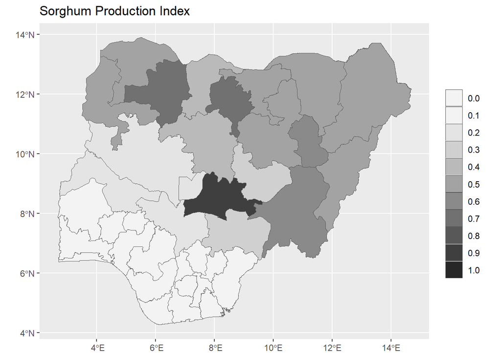

```r
vect_state_geo_sorghum_PI <- dplyr::left_join(vect_state_geo, df_sorghum_PI, by = "adm1_ref_name")

ggplot(vect_state_geo_sorghum_PI) +
  geom_spatvector(aes(fill = sorghum_PI)) +
  scale_fill_stepsn(
    n.breaks = 10,
    limits = c(0, 1),
    colours = hcl.colors(palette = "Grays", 10, rev = T),
    guide = "legend",
    na.value = "pink",
    labels = scales::comma
  ) +
  labs(title = "Sorghum Production Index", fill = "") +
  theme(
    plot.title = element_markdown(),
    legend.title = element_markdown(),
    axis.title = element_blank()
  )
```

#### Sweet Potato Production Index

```r
df_spot_PI <- left_join(
  select(df_crop_area_share_rescale, adm1_ref_name, spot_share_2022),
  select(df_crop_area_pc_rescale, adm1_ref_name, spot_pc_2022),
  by = "adm1_ref_name"
) |> mutate(spot_PI = ((spot_share_2022 * 0.5) + (spot_pc_2022 * 0.5)))

median_spot_PI <- median(df_spot_PI$spot_PI)
cat(paste("Median Sorghum PI = ", median_spot_PI))
```

Median Sorghum PI = 0.126544843009081

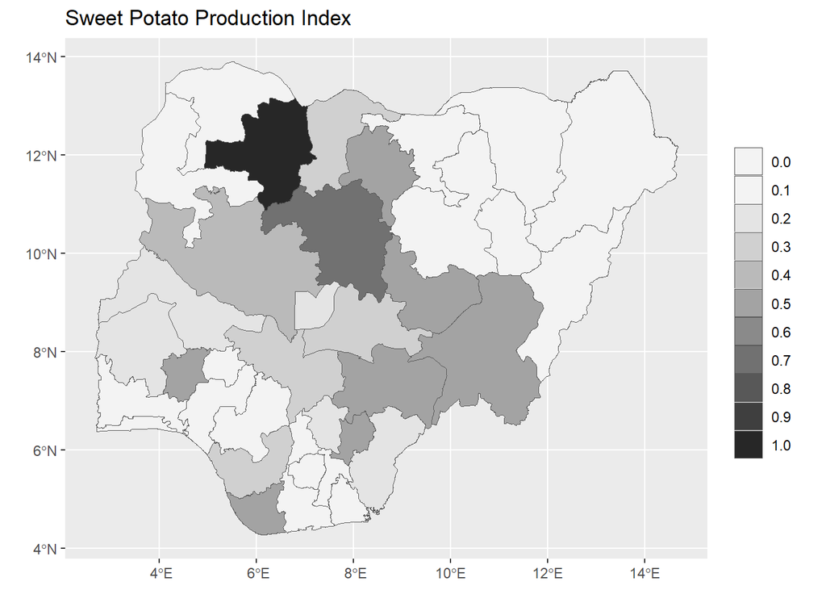

```r
vect_state_geo_spot_PI <- dplyr::left_join(vect_state_geo, df_spot_PI, by = "adm1_ref_name")

ggplot(vect_state_geo_spot_PI) +
  geom_spatvector(aes(fill = spot_PI)) +
  scale_fill_stepsn(
    n.breaks = 10,
    limits = c(0, 1),
    colours = hcl.colors(palette = "Grays", 10, rev = T),
    guide = "legend",
    na.value = "pink",
    labels = scales::comma
  ) +
  labs(title = "Sweet Potato Production Index", fill = "") +
  theme(
    plot.title = element_markdown(),
    legend.title = element_markdown(),
    axis.title = element_blank()
  )
```

### Consumption Index

Because we are not considering the import share the consumption index $CI_i$ for crop $i$ is simply the value of the rescaled consumption per capita for crop $i$.

### Micronutrient Indices

There is a separate index each for Vitamin A, Zinc and Iron:

#### Vitamin A deficiency Index

$$VAI = (0.5 * SR^r) + (0.5 * VAD^r) \tag{4}$$
Where:

- $VAI$ is the Micronutrient Index for Vitamin A
- $SR^r$ is the rescaled Serum Retinol 0.7
- $VAD^r$ is the rescaled DALYs by VAD

```r
df_VitA_I <- left_join(
  df_IHME_vit_A_DALYs_rescale, df_state,
    by = "adm1_ref_name") |>
  left_join(
   df_gpz,
    by = "adm1_pcode") |>
  left_join(df_NFCMS_vit_A_deficiency_CH_rescale, by = "geopolitical_zone") |> mutate(VitA_I = ((val * 0.5) + (CH_def_vit_A_pc_236 * 0.5)))

median_VitA_I <- median(df_VitA_I$VitA_I)
cat(paste("Median Vitamin A Deficiency Index = ", median_VitA_I))
```

Median Vitamin A Deficiency Index = 0.177423895927619

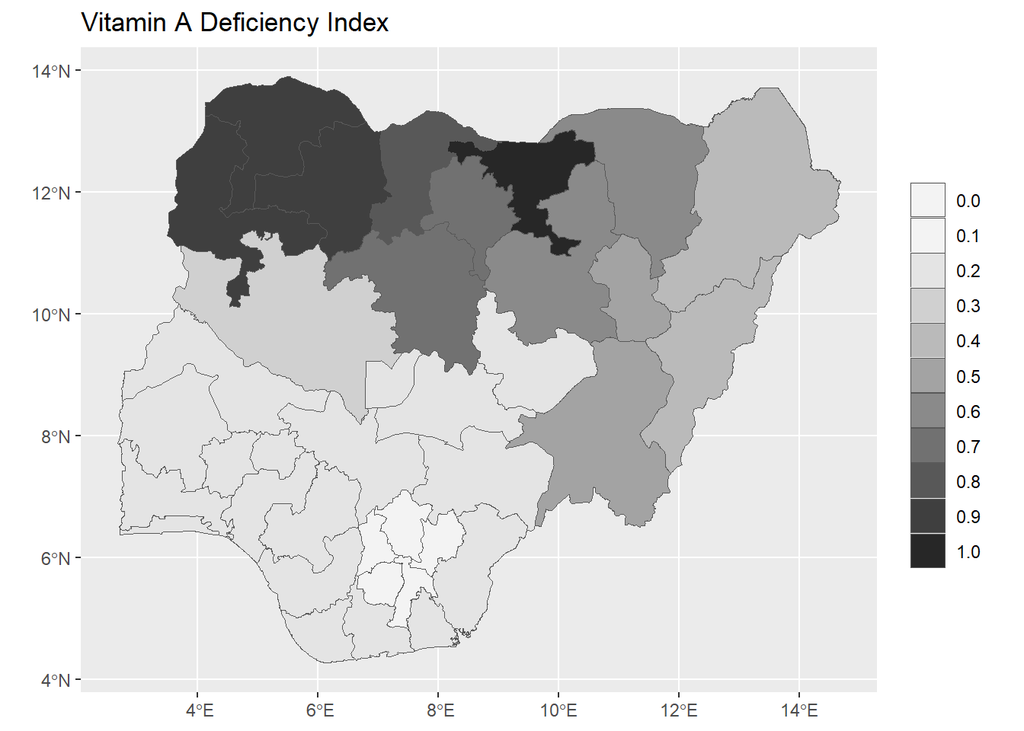

```r
vect_state_geo_VitA_I <- dplyr::left_join(vect_state_geo, df_VitA_I, by = "adm1_ref_name")

ggplot(vect_state_geo_VitA_I) +
  geom_spatvector(aes(fill = VitA_I)) +
  scale_fill_stepsn(
    n.breaks = 10,
    limits = c(0, 1),
    colours = hcl.colors(palette = "Grays", 10, rev = T),
    guide = "legend",
    na.value = "pink",
    labels = scales::comma
  ) +
  labs(title = "Vitamin A Deficiency Index", fill = "") +
  theme(
    plot.title = element_markdown(),
    legend.title = element_markdown(),
    axis.title = element_blank()
  )
```

#### Iron deficiency Index

$$FeI = (0.5 * HbD^r) + (0.5 * IDA^r) \tag{5}$$
Where:

- $FeI$ is the Micronutrient Index for Iron
- $HbD^r$ is the rescaled Hb below 110
- $IDA^r$ is the rescaled DALYs by IDA

```r
df_Fe_I <- left_join(
  df_IHME_iron_DALYs_rescale, df_NDHS_anaemia_combined_CH_rescale,
    by = "adm1_ref_name") |> mutate(Fe_I = ((val * 0.5) + (CH_anaemia_comb * 0.5)))

median_Fe_I <- median(df_Fe_I$Fe_I)
cat(paste("Median Iron Deficiency Index = ", median_Fe_I))
```

Median Iron Deficiency Index = 0.357816594465452

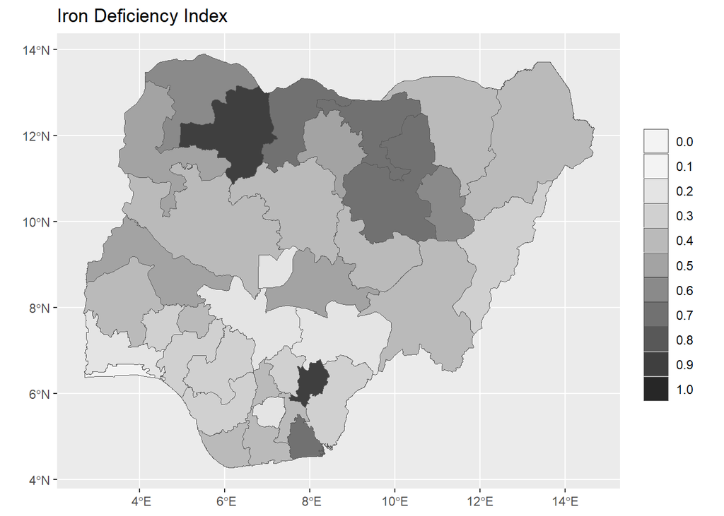

```r
vect_state_geo_Fe_I <- dplyr::left_join(vect_state_geo, df_Fe_I, by = "adm1_ref_name")

ggplot(vect_state_geo_Fe_I) +
  geom_spatvector(aes(fill = Fe_I)) +
  scale_fill_stepsn(
    n.breaks = 10,
    limits = c(0, 1),
    colours = hcl.colors(palette = "Grays", 10, rev = T),
    guide = "legend",
    na.value = "pink",
    labels = scales::comma
  ) +
  labs(title = "Iron Deficiency Index", fill = "") +
  theme(
    plot.title = element_markdown(),
    legend.title = element_markdown(),
    axis.title = element_blank()
  )
```

#### Zinc deficiency Index

$$ZnI = (0.5 * ((0.5 * ZnD_{WRA}^r) + (0.5 * ZnD_{CH}^r))) + (0.5 * St^r) \tag{6}$$
Where:

- $ZnI$ is the Micronutrient Index for Zinc
- $ZnD_{WRA}^r$ is the rescaled Zinc deficiency in women of reproductive age
- $ZnD_{CH}^r$ is the rescaled Zinc deficiency in children between 6-59 months
- $St^r$ is the rescaled prevalence of stunting among children between 6-59 months

```r
df_Zn_I <- left_join(df_NDHS_stunting_CH_rescale, df_state, by = c("state" = "adm1_ref_name")) |>
  left_join(df_gpz,by = "adm1_pcode")  |>
  left_join(df_NFCMS_zinc_deficiency_CH_rescale, by = "geopolitical_zone")   |>
  left_join(df_NFCMS_zinc_deficiency_WRA_rescale, by = "geopolitical_zone")   |>
  mutate(Zn_I = ((stunting_ndhs2024_pct * 0.5) + (((CH_def_zinc_pc_238 * 0.5) + (WRA_def_zinc_pc_252 * 0.5)) * 0.5)))

median_Zn_I <- median(df_Zn_I$Zn_I)
cat(paste("Median Zinc Deficiency Index = ", median_Zn_I))
```

Median Zinc Deficiency Index = 0.287082251698957

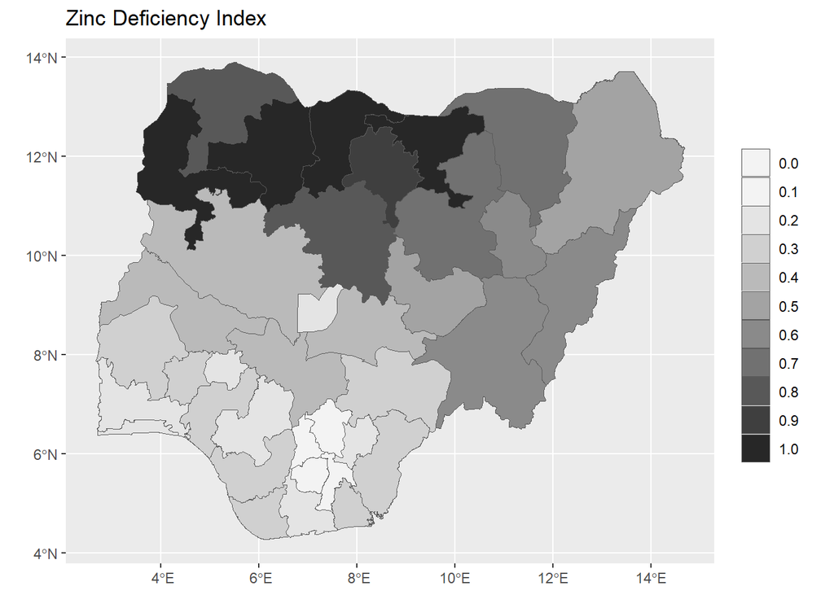

```r
vect_state_geo_Zn_I <- dplyr::left_join(vect_state_geo, df_Zn_I, by = c("adm1_ref_name" = "state"))

ggplot(vect_state_geo_Zn_I) +
  geom_spatvector(aes(fill = Zn_I)) +
  scale_fill_stepsn(
    n.breaks = 10,
    limits = c(0, 1),
    colours = hcl.colors(palette = "Grays", 10, rev = T),
    guide = "legend",
    na.value = "pink",
    labels = scales::comma
  ) +
  labs(title = "Zinc Deficiency Index", fill = "") +
  theme(
    plot.title = element_markdown(),
    legend.title = element_markdown(),
    axis.title = element_blank()
  )
```

## Unweighted Biofortification Priority Indices

| Crop | micronutrient |
| --- | --- |
| Banana/Plantain | Vitamin A |
| Cassava | Vitamin A |
| Cowpea | Zinc/Iron |
| Maize | Vitamin A |
| Maize | Zinc |
| Rice | Zinc |
| Sorghum | Zinc/Iron |
| Sweet Potato | Vitamin A |

The Biofortification Priority Index is calculated as:

$$BPI_{ij} = \sqrt{ \sqrt{(PI_i * CI_i)} * MDI_j)} \tag{7}$$
Where:

- $BPI_{ij}$ is the Biofortification Priority Index for crop $i$ and Micronutrient $j$
- $PI_i$ is the Production Index for crop $i$
- $CI_i$ is the Consumption Index for crop $i$
- $MDI_{j}$ is the Micronutrient Deficiency Index for Micronutrient $j$

### Plantain/Banana Vitamin A BPI

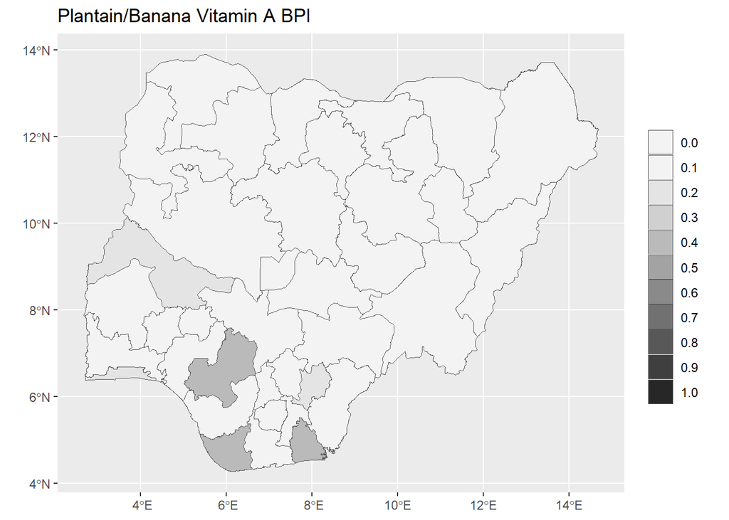

```r
df_plantain_banana_VitA_BPI <- left_join(df_plantain_banana_PI, df_GHS_pop_crop_state_rescale,
    by = c("adm1_ref_name"= "state")) |>
  left_join(df_VitA_I, by = "adm1_ref_name") |>
  mutate(plantain_banana_VitA_BPI = sqrt((sqrt(plantain_banana_PI * Plantain)) * VitA_I))



vect_state_geo_plantain_banana_VitA_BPI <- dplyr::left_join(vect_state_geo, df_plantain_banana_VitA_BPI, by = "adm1_ref_name")

ggplot(vect_state_geo_plantain_banana_VitA_BPI) +
  geom_spatvector(aes(fill = plantain_banana_VitA_BPI)) +
  scale_fill_stepsn(
    n.breaks = 10,
    limits = c(0, 1),
    colours = hcl.colors(palette = "Grays", 10, rev = T),
    guide = "legend",
    na.value = "pink",
    labels = scales::comma
  ) +
  labs(title = "Plantain/Banana Vitamin A BPI", fill = "") +
  theme(
    plot.title = element_markdown(),
    legend.title = element_markdown(),
    axis.title = element_blank()
  )
```

### Cassava Vitamin A BPI

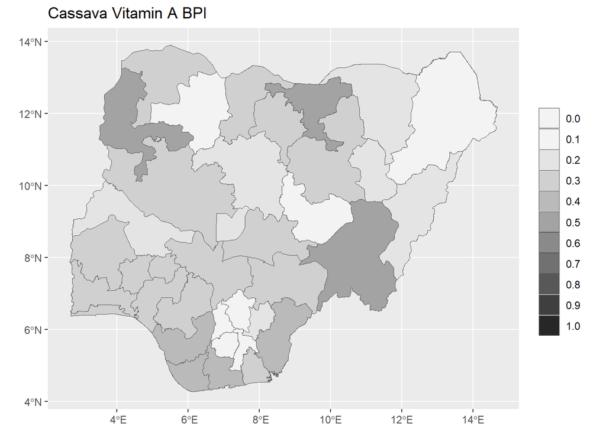

```r
df_cassava_VitA_BPI <- left_join(df_cassava_PI, df_GHS_pop_crop_state_rescale,
    by = c("adm1_ref_name"= "state")) |>
  left_join(df_VitA_I, by = "adm1_ref_name") |>
  mutate(cassava_VitA_BPI = sqrt((sqrt(cassava_PI * Cassava)) * VitA_I))



vect_state_geo_cassava_VitA_BPI <- dplyr::left_join(vect_state_geo, df_cassava_VitA_BPI, by = "adm1_ref_name")

ggplot(vect_state_geo_cassava_VitA_BPI) +
  geom_spatvector(aes(fill = cassava_VitA_BPI)) +
  scale_fill_stepsn(
    n.breaks = 10,
    limits = c(0, 1),
    colours = hcl.colors(palette = "Grays", 10, rev = T),
    guide = "legend",
    na.value = "pink",
    labels = scales::comma
  ) +
  labs(title = "Cassava Vitamin A BPI", fill = "") +
  theme(
    plot.title = element_markdown(),
    legend.title = element_markdown(),
    axis.title = element_blank()
  )
```

### Cowpea Zinc BPI

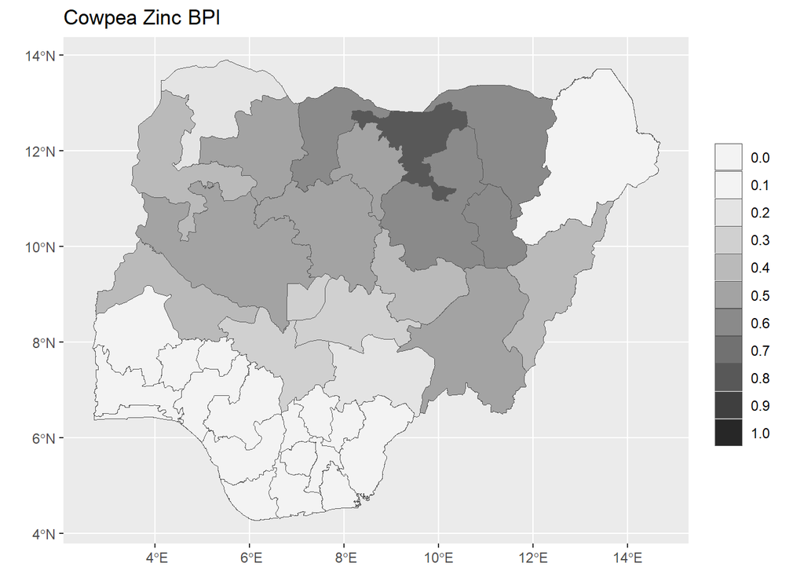

```r
df_cowpea_Zn_BPI <- left_join(df_cowpea_PI, df_GHS_pop_crop_state_rescale,
    by = c("adm1_ref_name"= "state")) |>
  left_join(df_Zn_I, c("adm1_ref_name"= "state")) |>
  mutate(cowpea_Zn_BPI = sqrt((sqrt(cowpea_PI * Cowpea)) * Zn_I))



vect_state_geo_cowpea_Zn_BPI <- dplyr::left_join(vect_state_geo, df_cowpea_Zn_BPI, by = "adm1_ref_name")

ggplot(vect_state_geo_cowpea_Zn_BPI) +
  geom_spatvector(aes(fill = cowpea_Zn_BPI)) +
  scale_fill_stepsn(
    n.breaks = 10,
    limits = c(0, 1),
    colours = hcl.colors(palette = "Grays", 10, rev = T),
    guide = "legend",
    na.value = "pink",
    labels = scales::comma
  ) +
  labs(title = "Cowpea Zinc BPI", fill = "") +
  theme(
    plot.title = element_markdown(),
    legend.title = element_markdown(),
    axis.title = element_blank()
  )
```

### Cowpea Iron BPI

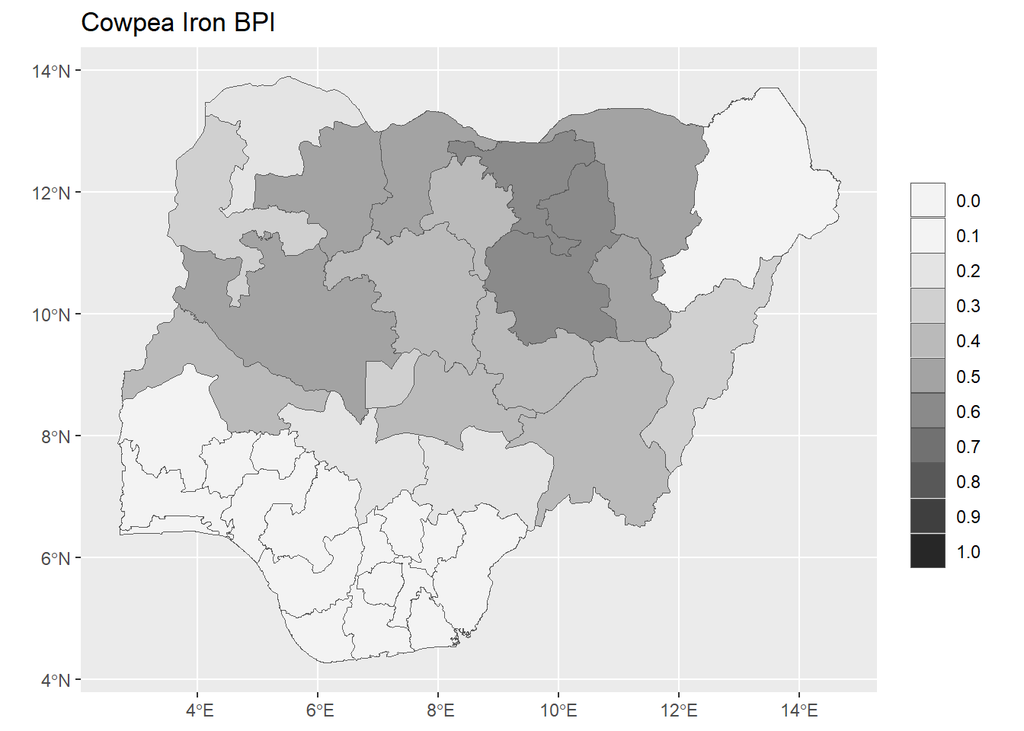

```r
df_cowpea_Fe_BPI <- left_join(df_cowpea_PI, df_GHS_pop_crop_state_rescale,
    by = c("adm1_ref_name"= "state")) |>
  left_join(df_Fe_I, "adm1_ref_name") |>
  mutate(cowpea_Fe_BPI = sqrt((sqrt(cowpea_PI * Cowpea)) * Fe_I))



vect_state_geo_cowpea_Fe_BPI <- dplyr::left_join(vect_state_geo, df_cowpea_Fe_BPI, by = "adm1_ref_name")

ggplot(vect_state_geo_cowpea_Fe_BPI) +
  geom_spatvector(aes(fill = cowpea_Fe_BPI)) +
  scale_fill_stepsn(
    n.breaks = 10,
    limits = c(0, 1),
    colours = hcl.colors(palette = "Grays", 10, rev = T),
    guide = "legend",
    na.value = "pink",
    labels = scales::comma
  ) +
  labs(title = "Cowpea Iron BPI", fill = "") +
  theme(
    plot.title = element_markdown(),
    legend.title = element_markdown(),
    axis.title = element_blank()
  )
```

### Maize Vitamin A BPI

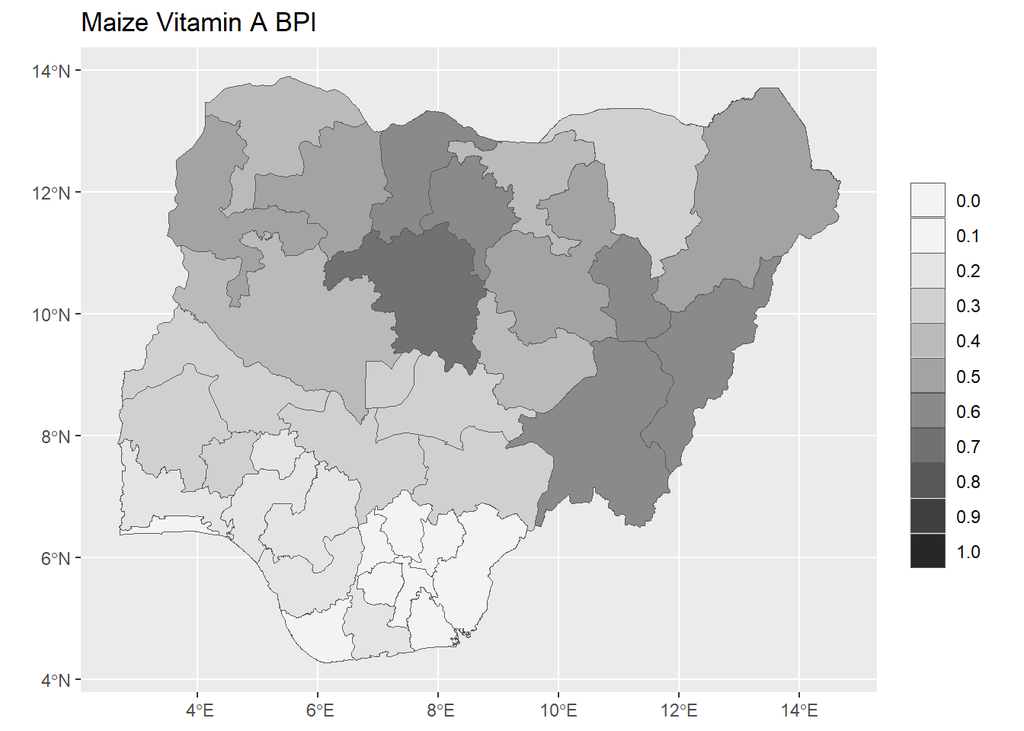

```r
df_maize_VitA_BPI <- left_join(df_maize_PI, df_GHS_pop_crop_state_rescale,
    by = c("adm1_ref_name"= "state")) |>
  left_join(df_VitA_I, by = "adm1_ref_name") |>
  mutate(maize_VitA_BPI = sqrt((sqrt(maize_PI * Maize)) * VitA_I))



vect_state_geo_maize_VitA_BPI <- dplyr::left_join(vect_state_geo, df_maize_VitA_BPI, by = "adm1_ref_name")

ggplot(vect_state_geo_maize_VitA_BPI) +
  geom_spatvector(aes(fill = maize_VitA_BPI)) +
  scale_fill_stepsn(
    n.breaks = 10,
    limits = c(0, 1),
    colours = hcl.colors(palette = "Grays", 10, rev = T),
    guide = "legend",
    na.value = "pink",
    labels = scales::comma
  ) +
  labs(title = "Maize Vitamin A BPI", fill = "") +
  theme(
    plot.title = element_markdown(),
    legend.title = element_markdown(),
    axis.title = element_blank()
  )
```

### Maize Zinc BPI

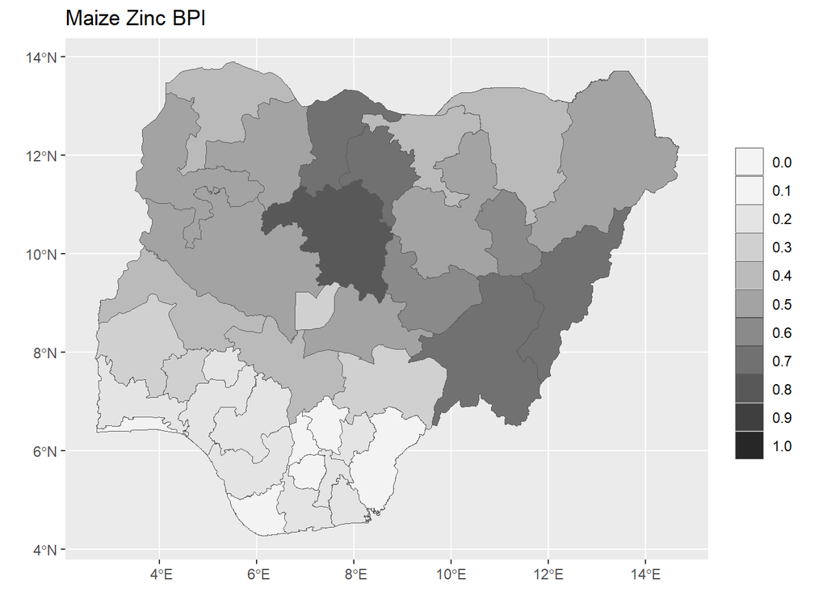

```r
df_maize_Zn_BPI <- left_join(df_maize_PI, df_GHS_pop_crop_state_rescale,
    by = c("adm1_ref_name"= "state")) |>
  left_join(df_Zn_I, c("adm1_ref_name"= "state")) |>
  mutate(maize_Zn_BPI = sqrt((sqrt(maize_PI * Maize)) * Zn_I))



vect_state_geo_maize_Zn_BPI <- dplyr::left_join(vect_state_geo, df_maize_Zn_BPI, by = "adm1_ref_name")

ggplot(vect_state_geo_maize_Zn_BPI) +
  geom_spatvector(aes(fill = maize_Zn_BPI)) +
  scale_fill_stepsn(
    n.breaks = 10,
    limits = c(0, 1),
    colours = hcl.colors(palette = "Grays", 10, rev = T),
    guide = "legend",
    na.value = "pink",
    labels = scales::comma
  ) +
  labs(title = "Maize Zinc BPI", fill = "") +
  theme(
    plot.title = element_markdown(),
    legend.title = element_markdown(),
    axis.title = element_blank()
  )
```

### Rice Zinc BPI

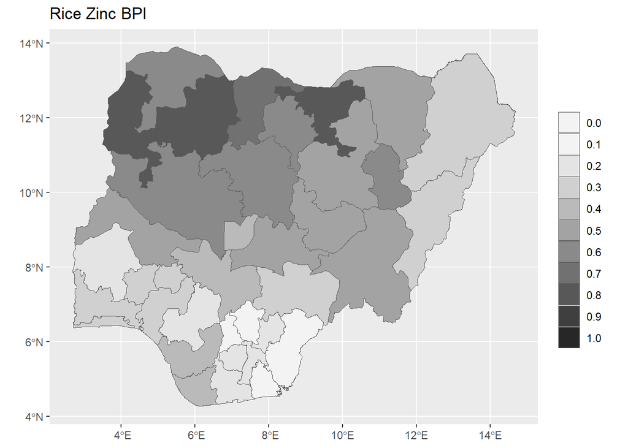

```r
df_rice_Zn_BPI <- left_join(df_rice_PI, df_GHS_pop_crop_state_rescale,
    by = c("adm1_ref_name"= "state")) |>
  left_join(df_Zn_I, c("adm1_ref_name"= "state")) |>
  mutate(rice_Zn_BPI = sqrt((sqrt(rice_PI * Rice)) * Zn_I))



vect_state_geo_rice_Zn_BPI <- dplyr::left_join(vect_state_geo, df_rice_Zn_BPI, by = "adm1_ref_name")

ggplot(vect_state_geo_rice_Zn_BPI) +
  geom_spatvector(aes(fill = rice_Zn_BPI)) +
  scale_fill_stepsn(
    n.breaks = 10,
    limits = c(0, 1),
    colours = hcl.colors(palette = "Grays", 10, rev = T),
    guide = "legend",
    na.value = "pink",
    labels = scales::comma
  ) +
  labs(title = "Rice Zinc BPI", fill = "") +
  theme(
    plot.title = element_markdown(),
    legend.title = element_markdown(),
    axis.title = element_blank()
  )
```

### Sorghum Zinc BPI

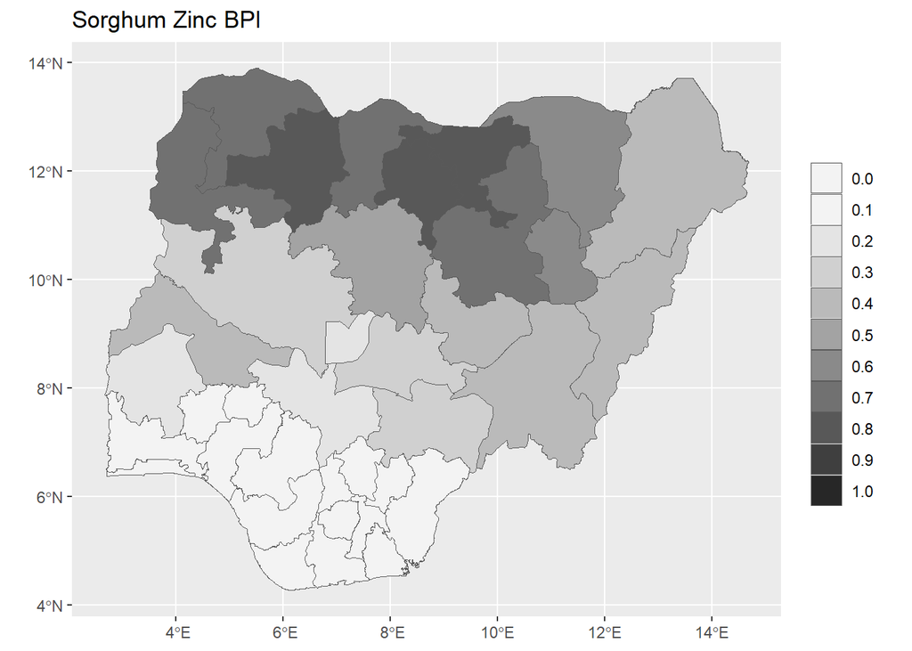

```r
df_sorghum_Zn_BPI <- left_join(df_sorghum_PI, df_GHS_pop_crop_state_rescale,
    by = c("adm1_ref_name"= "state")) |>
  left_join(df_Zn_I, c("adm1_ref_name"= "state")) |>
  mutate(sorghum_Zn_BPI = sqrt((sqrt(sorghum_PI * Sorghum)) * Zn_I))



vect_state_geo_sorghum_Zn_BPI <- dplyr::left_join(vect_state_geo, df_sorghum_Zn_BPI, by = "adm1_ref_name")

ggplot(vect_state_geo_sorghum_Zn_BPI) +
  geom_spatvector(aes(fill = sorghum_Zn_BPI)) +
  scale_fill_stepsn(
    n.breaks = 10,
    limits = c(0, 1),
    colours = hcl.colors(palette = "Grays", 10, rev = T),
    guide = "legend",
    na.value = "pink",
    labels = scales::comma
  ) +
  labs(title = "Sorghum Zinc BPI", fill = "") +
  theme(
    plot.title = element_markdown(),
    legend.title = element_markdown(),
    axis.title = element_blank()
  )
```

### Sorghum Iron BPI

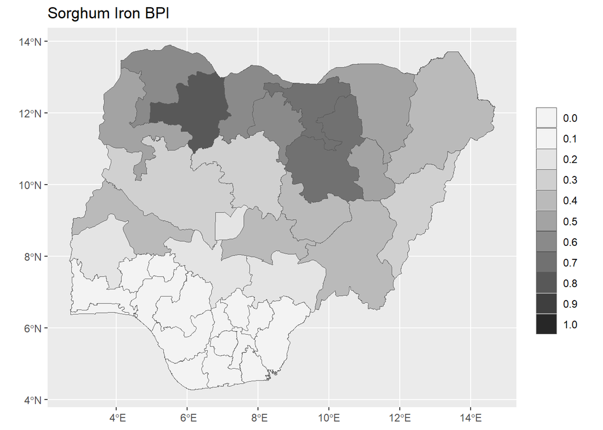

```r
df_sorghum_Fe_BPI <- left_join(df_sorghum_PI, df_GHS_pop_crop_state_rescale,
    by = c("adm1_ref_name"= "state")) |>
  left_join(df_Fe_I, "adm1_ref_name") |>
  mutate(sorghum_Fe_BPI = sqrt((sqrt(sorghum_PI * Sorghum)) * Fe_I))



vect_state_geo_sorghum_Fe_BPI <- dplyr::left_join(vect_state_geo, df_sorghum_Fe_BPI, by = "adm1_ref_name")

ggplot(vect_state_geo_sorghum_Fe_BPI) +
  geom_spatvector(aes(fill = sorghum_Fe_BPI)) +
  scale_fill_stepsn(
    n.breaks = 10,
    limits = c(0, 1),
    colours = hcl.colors(palette = "Grays", 10, rev = T),
    guide = "legend",
    na.value = "pink",
    labels = scales::comma
  ) +
  labs(title = "Sorghum Iron BPI", fill = "") +
  theme(
    plot.title = element_markdown(),
    legend.title = element_markdown(),
    axis.title = element_blank()
  )
```

### Sweet Potato Vitamin A BPI

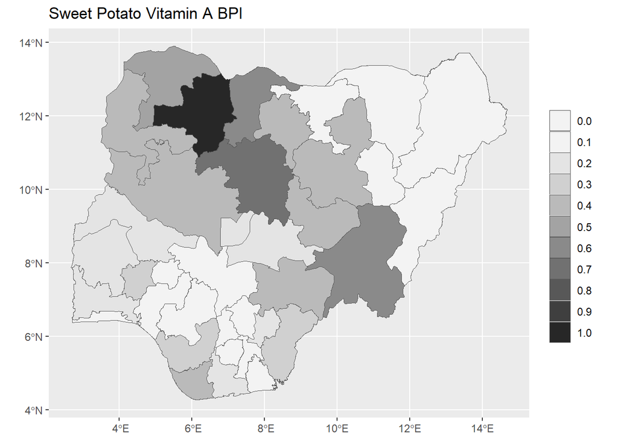

```r
df_spot_VitA_BPI <- left_join(df_spot_PI, df_GHS_pop_crop_state_rescale,
    by = c("adm1_ref_name"= "state")) |>
  left_join(df_VitA_I, by = "adm1_ref_name") |>
  mutate(spot_VitA_BPI = sqrt((sqrt(spot_PI * Sweet.potato)) * VitA_I))



vect_state_geo_spot_VitA_BPI <- dplyr::left_join(vect_state_geo, df_spot_VitA_BPI, by = "adm1_ref_name")

ggplot(vect_state_geo_spot_VitA_BPI) +
  geom_spatvector(aes(fill = spot_VitA_BPI)) +
  scale_fill_stepsn(
    n.breaks = 10,
    limits = c(0, 1),
    colours = hcl.colors(palette = "Grays", 10, rev = T),
    guide = "legend",
    na.value = "pink",
    labels = scales::comma
  ) +
  labs(title = "Sweet Potato Vitamin A BPI", fill = "") +
  theme(
    plot.title = element_markdown(),
    legend.title = element_markdown(),
    axis.title = element_blank()
  )
```

## Rescaled unweighted Biofortification Priority Indices

Asare-Marfo et al. (2013) make further modificiations to the raw BPIs for each crop/micronutrient combination. They multiply the raw BPI by 100 and then rescale so that the geographical unit with the highest value receives a value of 100 while the lowest receives a value of 0.

This is useful for comparing the different units but some information is lost regarding the absolute values and is less useful for comparing different crop/MN combinations.

```r
breaks_priority <- c(3, 10, 20, 50, 100)

colours_priority <- c("#6DC700", "#CCFF00", "#FFC800", "#FF6600", "#B00000")

labels_priority = c("Little/no", "Low", "Medium", "High", "Top" )
```

### Plantain/Banana Vitamin A BPI

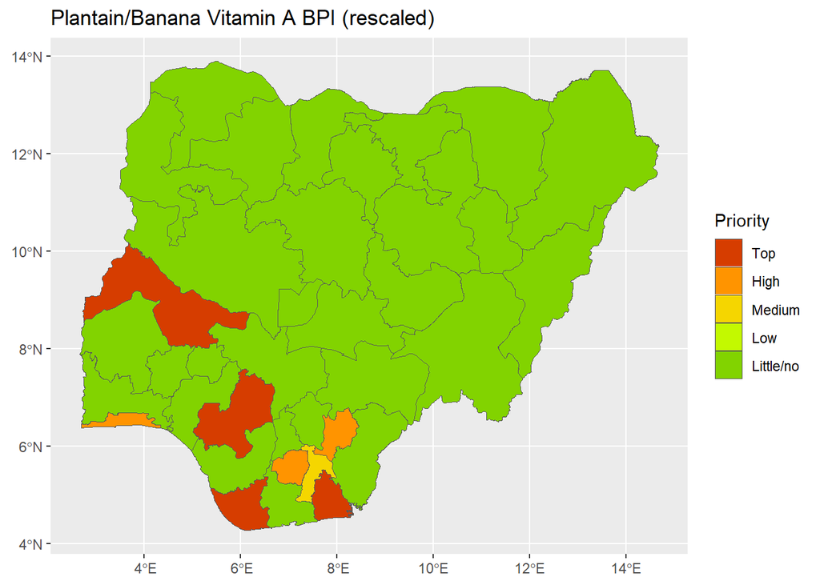

```r
df_plantain_banana_VitA_BPI_normalised <- as.data.frame(lapply(select(df_plantain_banana_VitA_BPI, plantain_banana_VitA_BPI ), minMax)) |>
  mutate(plantain_banana_VitA_BPI_rescale = (plantain_banana_VitA_BPI * 100))

df_plantain_banana_VitA_BPI_rescale <- bind_cols(select(df_plantain_banana_VitA_BPI, adm1_ref_name), select(df_plantain_banana_VitA_BPI_normalised, plantain_banana_VitA_BPI_rescale ))

vect_state_geo_plantain_banana_VitA_BPI_rescale <- dplyr::left_join(vect_state_geo, df_plantain_banana_VitA_BPI_rescale, by = "adm1_ref_name")

ggplot(vect_state_geo_plantain_banana_VitA_BPI_rescale) +
  geom_spatvector(aes(fill = plantain_banana_VitA_BPI_rescale)) +
  scale_fill_stepsn(
    colors = colours_priority,
    values = scales::rescale(breaks_priority),
    breaks = breaks_priority,
    limits = c(0, 100),
    na.value = "grey",
    labels = labels_priority
  ) +
  guides(fill = guide_legend(reverse=T)) +
  labs(title = "Plantain/Banana Vitamin A BPI (rescaled)", fill = "Priority") +
  theme(
    plot.title = element_markdown(),
    legend.title = element_markdown(),
    axis.title = element_blank()
  )
```

### Cassava Vitamin A BPI

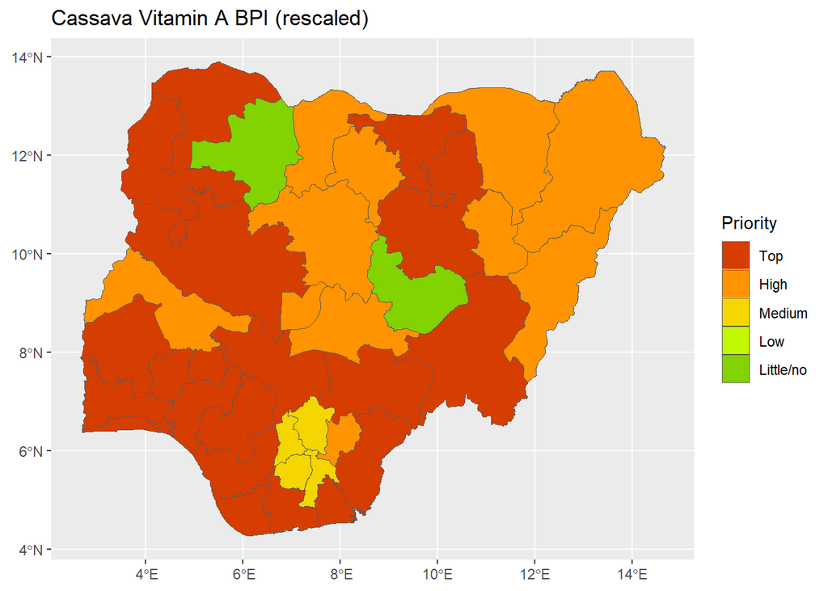

```r
df_cassava_VitA_BPI_normalised <- as.data.frame(lapply(select(df_cassava_VitA_BPI, cassava_VitA_BPI ), minMax)) |>
  mutate(cassava_VitA_BPI_rescale = (cassava_VitA_BPI * 100))

df_cassava_VitA_BPI_rescale <- bind_cols(select(df_cassava_VitA_BPI, adm1_ref_name), select(df_cassava_VitA_BPI_normalised, cassava_VitA_BPI_rescale ))

vect_state_geo_cassava_VitA_BPI_rescale <- dplyr::left_join(vect_state_geo, df_cassava_VitA_BPI_rescale, by = "adm1_ref_name")

ggplot(vect_state_geo_cassava_VitA_BPI_rescale) +
  geom_spatvector(aes(fill = cassava_VitA_BPI_rescale)) +
  scale_fill_stepsn(
    colors = colours_priority,
    values = scales::rescale(breaks_priority),
    breaks = breaks_priority,
    limits = c(0, 100),
    na.value = "grey",
    labels = labels_priority
  ) +
  guides(fill = guide_legend(reverse=T)) +
  labs(title = "Cassava Vitamin A BPI (rescaled)", fill = "Priority") +
  theme(
    plot.title = element_markdown(),
    legend.title = element_markdown(),
    axis.title = element_blank()
  )
```

### Cowpea Zinc BPI

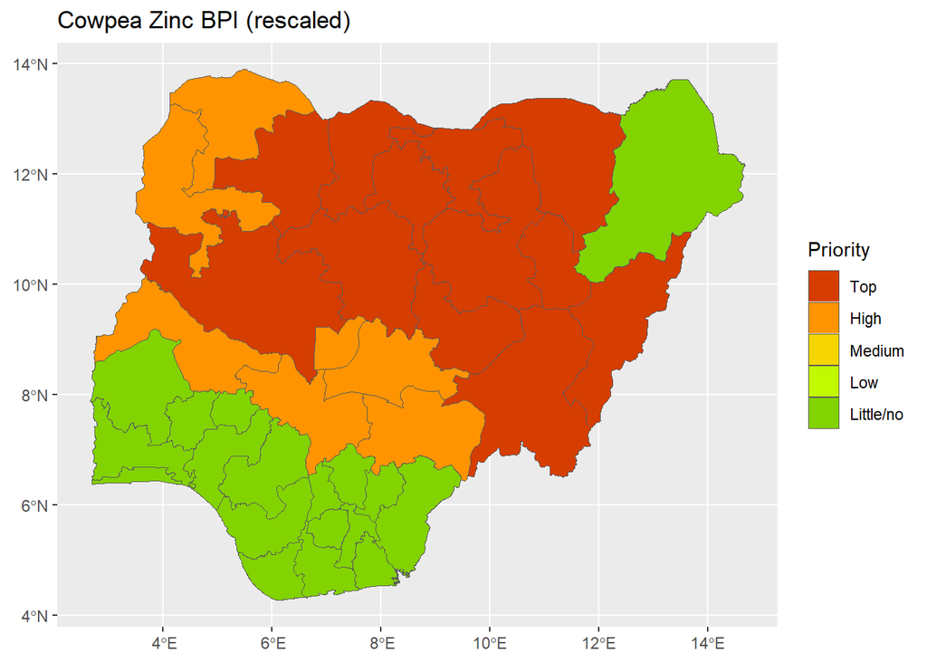

```r
df_cowpea_Zn_BPI_normalised <- as.data.frame(lapply(select(df_cowpea_Zn_BPI, cowpea_Zn_BPI ), minMax)) |>
  mutate(cowpea_Zn_BPI_rescale = (cowpea_Zn_BPI * 100))

df_cowpea_Zn_BPI_rescale <- bind_cols(select(df_cowpea_Zn_BPI, adm1_ref_name), select(df_cowpea_Zn_BPI_normalised, cowpea_Zn_BPI_rescale ))

vect_state_geo_cowpea_Zn_BPI_rescale <- dplyr::left_join(vect_state_geo, df_cowpea_Zn_BPI_rescale, by = "adm1_ref_name")

ggplot(vect_state_geo_cowpea_Zn_BPI_rescale) +
  geom_spatvector(aes(fill = cowpea_Zn_BPI_rescale)) +
  scale_fill_stepsn(
    colors = colours_priority,
    values = scales::rescale(breaks_priority),
    breaks = breaks_priority,
    limits = c(0, 100),
    na.value = "grey",
    labels = labels_priority
  ) +
  guides(fill = guide_legend(reverse=T)) +
  labs(title = "Cowpea Zinc BPI (rescaled)", fill = "Priority") +
  theme(
    plot.title = element_markdown(),
    legend.title = element_markdown(),
    axis.title = element_blank()
  )
```

### Cowpea Iron BPI

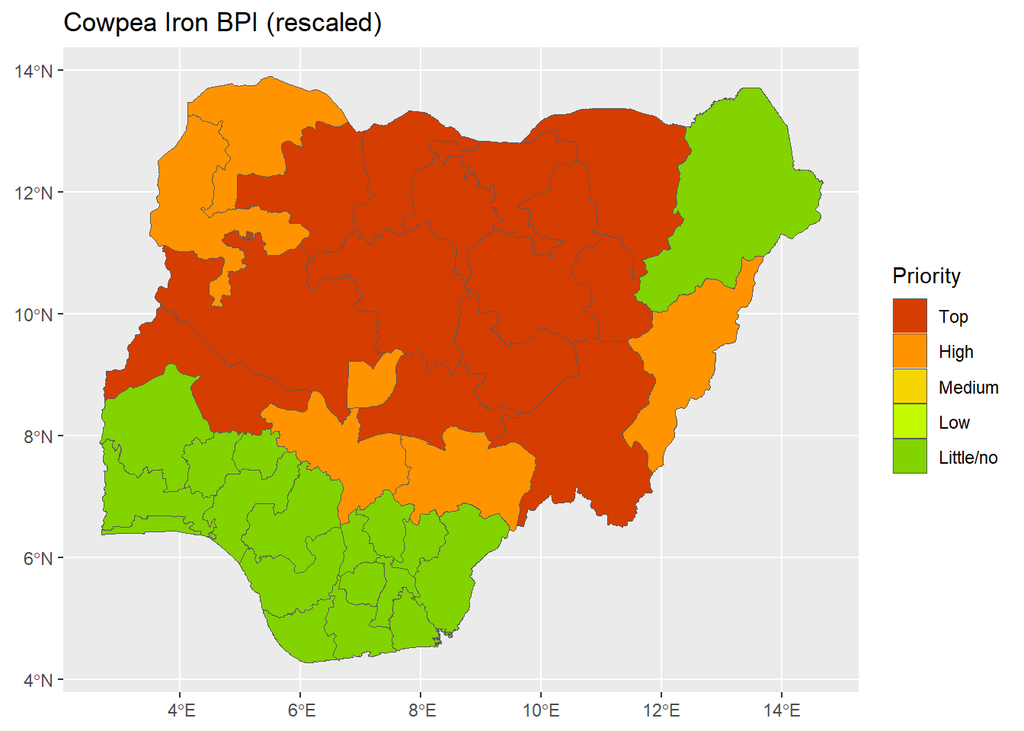

```r
df_cowpea_Fe_BPI_normalised <- as.data.frame(lapply(select(df_cowpea_Fe_BPI, cowpea_Fe_BPI ), minMax)) |>
  mutate(cowpea_Fe_BPI_rescale = (cowpea_Fe_BPI * 100))

df_cowpea_Fe_BPI_rescale <- bind_cols(select(df_cowpea_Fe_BPI, adm1_ref_name), select(df_cowpea_Fe_BPI_normalised, cowpea_Fe_BPI_rescale ))

vect_state_geo_cowpea_Fe_BPI_rescale <- dplyr::left_join(vect_state_geo, df_cowpea_Fe_BPI_rescale, by = "adm1_ref_name")

ggplot(vect_state_geo_cowpea_Fe_BPI_rescale) +
  geom_spatvector(aes(fill = cowpea_Fe_BPI_rescale)) +
  scale_fill_stepsn(
    colors = colours_priority,
    values = scales::rescale(breaks_priority),
    breaks = breaks_priority,
    limits = c(0, 100),
    na.value = "grey",
    labels = labels_priority
  ) +
  guides(fill = guide_legend(reverse=T)) +
  labs(title = "Cowpea Iron BPI (rescaled)", fill = "Priority") +
  theme(
    plot.title = element_markdown(),
    legend.title = element_markdown(),
    axis.title = element_blank()
  )
```

### Maize Vitamin A BPI

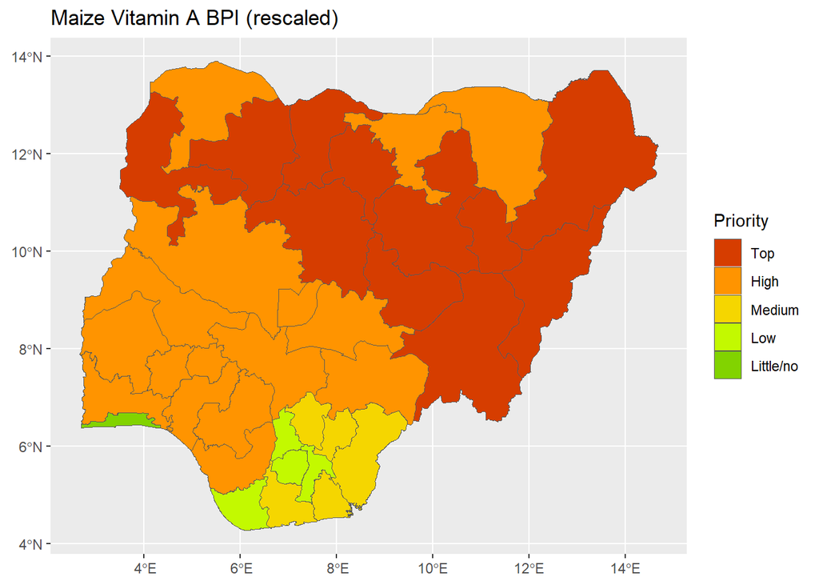

```r
df_maize_VitA_BPI_normalised <- as.data.frame(lapply(select(df_maize_VitA_BPI, maize_VitA_BPI ), minMax)) |>
  mutate(maize_VitA_BPI_rescale = (maize_VitA_BPI * 100))

df_maize_VitA_BPI_rescale <- bind_cols(select(df_maize_VitA_BPI, adm1_ref_name), select(df_maize_VitA_BPI_normalised, maize_VitA_BPI_rescale ))

vect_state_geo_maize_VitA_BPI_rescale <- dplyr::left_join(vect_state_geo, df_maize_VitA_BPI_rescale, by = "adm1_ref_name")

ggplot(vect_state_geo_maize_VitA_BPI_rescale) +
  geom_spatvector(aes(fill = maize_VitA_BPI_rescale)) +
  scale_fill_stepsn(
    colors = colours_priority,
    values = scales::rescale(breaks_priority),
    breaks = breaks_priority,
    limits = c(0, 100),
    na.value = "grey",
    labels = labels_priority
  ) +
  guides(fill = guide_legend(reverse=T)) +
  labs(title = "Maize Vitamin A BPI (rescaled)", fill = "Priority") +
  theme(
    plot.title = element_markdown(),
    legend.title = element_markdown(),
    axis.title = element_blank()
  )
```

### Maize Zinc BPI

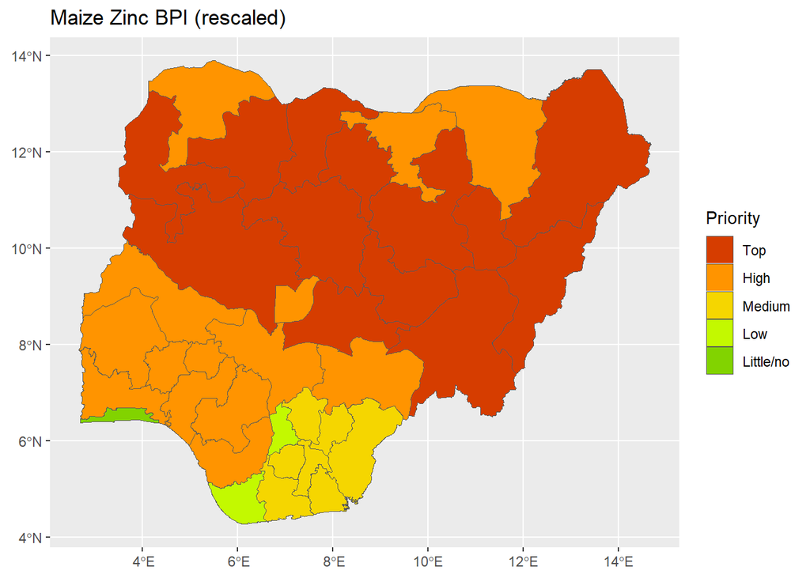

```r
df_maize_Zn_BPI_normalised <- as.data.frame(lapply(select(df_maize_Zn_BPI, maize_Zn_BPI ), minMax)) |>
  mutate(maize_Zn_BPI_rescale = (maize_Zn_BPI * 100))

df_maize_Zn_BPI_rescale <- bind_cols(select(df_maize_Zn_BPI, adm1_ref_name), select(df_maize_Zn_BPI_normalised, maize_Zn_BPI_rescale ))

vect_state_geo_maize_Zn_BPI_rescale <- dplyr::left_join(vect_state_geo, df_maize_Zn_BPI_rescale, by = "adm1_ref_name")

ggplot(vect_state_geo_maize_Zn_BPI_rescale) +
  geom_spatvector(aes(fill = maize_Zn_BPI_rescale)) +
  scale_fill_stepsn(
    colors = colours_priority,
    values = scales::rescale(breaks_priority),
    breaks = breaks_priority,
    limits = c(0, 100),
    na.value = "grey",
    labels = labels_priority
  ) +
  guides(fill = guide_legend(reverse=T)) +
  labs(title = "Maize Zinc BPI (rescaled)", fill = "Priority") +
  theme(
    plot.title = element_markdown(),
    legend.title = element_markdown(),
    axis.title = element_blank()
  )
```

### Rice Zinc BPI

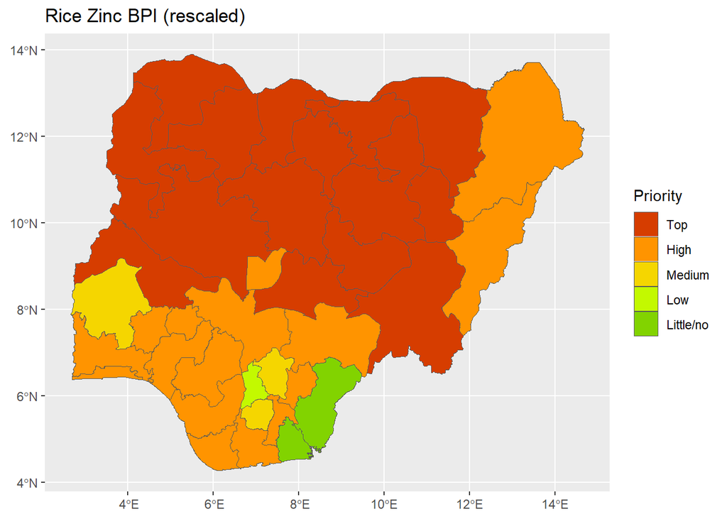

```r
df_rice_Zn_BPI_normalised <- as.data.frame(lapply(select(df_rice_Zn_BPI, rice_Zn_BPI ), minMax)) |>
  mutate(rice_Zn_BPI_rescale = (rice_Zn_BPI * 100))

df_rice_Zn_BPI_rescale <- bind_cols(select(df_rice_Zn_BPI, adm1_ref_name), select(df_rice_Zn_BPI_normalised, rice_Zn_BPI_rescale ))

vect_state_geo_rice_Zn_BPI_rescale <- dplyr::left_join(vect_state_geo, df_rice_Zn_BPI_rescale, by = "adm1_ref_name")

ggplot(vect_state_geo_rice_Zn_BPI_rescale) +
  geom_spatvector(aes(fill = rice_Zn_BPI_rescale)) +
  scale_fill_stepsn(
    colors = colours_priority,
    values = scales::rescale(breaks_priority),
    breaks = breaks_priority,
    limits = c(0, 100),
    na.value = "grey",
    labels = labels_priority
  ) +
  guides(fill = guide_legend(reverse=T)) +
  labs(title = "Rice Zinc BPI (rescaled)", fill = "Priority") +
  theme(
    plot.title = element_markdown(),
    legend.title = element_markdown(),
    axis.title = element_blank()
  )
```

### Sorghum Zinc BPI

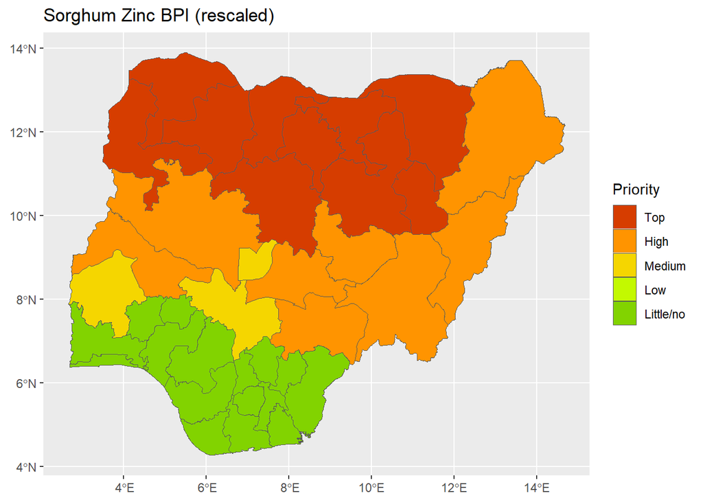

```r
df_sorghum_Zn_BPI_normalised <- as.data.frame(lapply(select(df_sorghum_Zn_BPI, sorghum_Zn_BPI ), minMax)) |>
  mutate(sorghum_Zn_BPI_rescale = (sorghum_Zn_BPI * 100))

df_sorghum_Zn_BPI_rescale <- bind_cols(select(df_sorghum_Zn_BPI, adm1_ref_name), select(df_sorghum_Zn_BPI_normalised, sorghum_Zn_BPI_rescale ))

vect_state_geo_sorghum_Zn_BPI_rescale <- dplyr::left_join(vect_state_geo, df_sorghum_Zn_BPI_rescale, by = "adm1_ref_name")

ggplot(vect_state_geo_sorghum_Zn_BPI_rescale) +
  geom_spatvector(aes(fill = sorghum_Zn_BPI_rescale)) +
  scale_fill_stepsn(
    colors = colours_priority,
    values = scales::rescale(breaks_priority),
    breaks = breaks_priority,
    limits = c(0, 100),
    na.value = "grey",
    labels = labels_priority
  ) +
  guides(fill = guide_legend(reverse=T)) +
  labs(title = "Sorghum Zinc BPI (rescaled)", fill = "Priority") +
  theme(
    plot.title = element_markdown(),
    legend.title = element_markdown(),
    axis.title = element_blank()
  )
```

### Sorghum Iron BPI

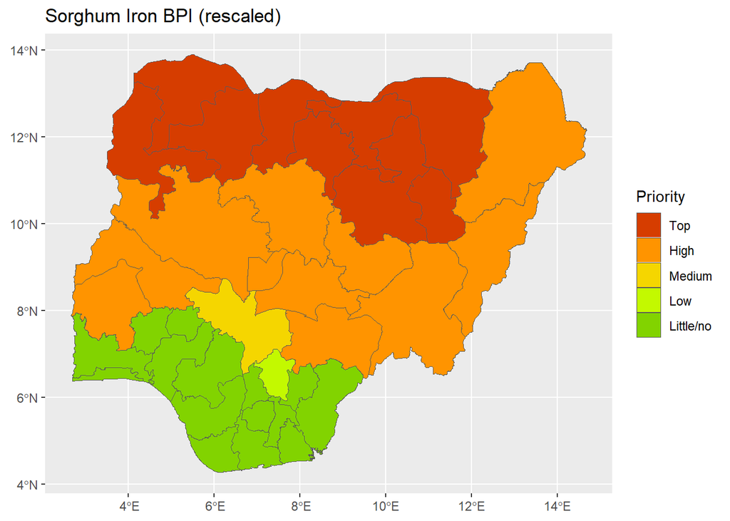

```r
df_sorghum_Fe_BPI_normalised <- as.data.frame(lapply(select(df_sorghum_Fe_BPI, sorghum_Fe_BPI ), minMax)) |>
  mutate(sorghum_Fe_BPI_rescale = (sorghum_Fe_BPI * 100))

df_sorghum_Fe_BPI_rescale <- bind_cols(select(df_sorghum_Fe_BPI, adm1_ref_name), select(df_sorghum_Fe_BPI_normalised, sorghum_Fe_BPI_rescale ))

vect_state_geo_sorghum_Fe_BPI_rescale <- dplyr::left_join(vect_state_geo, df_sorghum_Fe_BPI_rescale, by = "adm1_ref_name")

ggplot(vect_state_geo_sorghum_Fe_BPI_rescale) +
  geom_spatvector(aes(fill = sorghum_Fe_BPI_rescale)) +
  scale_fill_stepsn(
    colors = colours_priority,
    values = scales::rescale(breaks_priority),
    breaks = breaks_priority,
    limits = c(0, 100),
    na.value = "grey",
    labels = labels_priority
  ) +
  guides(fill = guide_legend(reverse=T)) +
  labs(title = "Sorghum Iron BPI (rescaled)", fill = "Priority") +
  theme(
    plot.title = element_markdown(),
    legend.title = element_markdown(),
    axis.title = element_blank()
  )
```

### Sweet Potato Vitamin A BPI

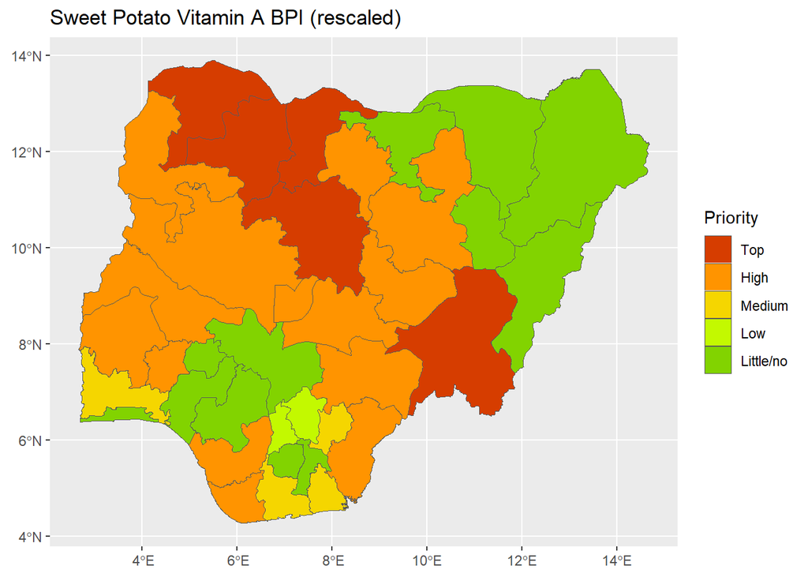

```r
df_spot_VitA_BPI_normalised <- as.data.frame(lapply(select(df_spot_VitA_BPI, spot_VitA_BPI ), minMax)) |>
  mutate(spot_VitA_BPI_rescale = (spot_VitA_BPI * 100))

df_spot_VitA_BPI_rescale <- bind_cols(select(df_spot_VitA_BPI, adm1_ref_name), select(df_spot_VitA_BPI_normalised, spot_VitA_BPI_rescale ))

vect_state_geo_spot_VitA_BPI_rescale <- dplyr::left_join(vect_state_geo, df_spot_VitA_BPI_rescale, by = "adm1_ref_name")

ggplot(vect_state_geo_spot_VitA_BPI_rescale) +
  geom_spatvector(aes(fill = spot_VitA_BPI_rescale)) +
  scale_fill_stepsn(
    colors = colours_priority,
    values = scales::rescale(breaks_priority),
    breaks = breaks_priority,
    limits = c(0, 100),
    na.value = "grey",
    labels = labels_priority
  ) +
  guides(fill = guide_legend(reverse=T)) +
  labs(title = "Sweet Potato Vitamin A BPI (rescaled)", fill = "Priority") +
  theme(
    plot.title = element_markdown(),
    legend.title = element_markdown(),
    axis.title = element_blank()
  )
```

## Target Area Classification

Herrington et al. (2018), extended the subnational BPI with a classification of the geographical units according to an alternative combination of the BPI sub components.

They identified states where consumption and micronutrient deficiency levels were lower than average, but where production was higher than average, called *Areas of Intervention*. States with consumption and micronutrient deficiency levels above or equal to the national average were classed as *Areas of Impact*. States where consumption, production and micronutrient deficiency were all above average were classed as *Areas of Impact and Intervention*.

$$GIntImp = CI_i > \tilde{C_i} \land PI_i > \tilde{P_i} \land MDI_j > \tilde{MD_j}
\tag{8}$$

$$GImp = CI_i \geq \tilde{C_i} \land PI_i \leq \tilde{P_i} \land MDI_j \geq \tilde{MD_j}
\tag{9}$$

$$GInt = CI_i < \tilde{C_i} \land PI_i > \tilde{P_i} \land MDI_j < \tilde{MD_j}
\tag{10}$$

Where:

- $GIntImp$ are geographical areas for both Intervention and Impact
- $GImp$ are geographical areas for Impact only
- $GInt$ are geographical areas for Intervention only
- $CI_i$ is the consumption index for crop $i$
- $\tilde{C_i}$ is the median consumption for crop $i$
- $PI_i$ is the production index for crop $i$
- $\tilde{P_i}$ is the median production for crop $i$
- $MDI_j$ is the micronutrient deficiency index for micronutrient $j$
- $\tilde{MD_j}$ is the median micronutrient deficiency for micronutrient $j$

These classes are useful for translating the subnational BPI maps into concrete actions on the ground to reduce micronutrient deficiency by biofortification of staple crops. Herrington et al. (2018) do not give details on how they compare the indices (which are unit less) with the consumption, production and micronutrient deficiency levels.

For our purposes we will not use the actual consumption, production or deficiency values, instead we will compare a state’s index with the median index value of all states.

$$GIntImp = CI_i > \tilde{CI_i} \land PI_i > \tilde{PI_i} \land MDI_j > \tilde{MDI_j}
\tag{11}$$

$$GImp = CI_i \geq \tilde{CI_i} \land PI_i \leq \tilde{PI_i} \land MDI_j \geq \tilde{MDI_j}
\tag{12}$$

$$GInt = CI_i < \tilde{CI_i} \land PI_i > \tilde{PI_i} \land MDI_j < \tilde{MDI_j}
\tag{13}$$

Where:

- $CI_i$ is the consumption index for crop $i$
- $\tilde{C_i}$ is the median consumption for crop $i$
- $PI_i$ is the production index for crop $i$
- $\tilde{P_i}$ is the median production for crop $i$
- $MDI_j$ is the micronutrient deficiency index for micronutrient $j$
- $\tilde{MD_j}$ is the median micronutrient deficiency for micronutrient $j$

```r
area_colours <- c(
  "Intervention and Impact Areas"    = "green",
  "Impact Areas" = "orange",
  "Intervention Areas"   = "lightblue",
  "None"       = "white"
)

area_breaks_target <- c("Intervention and Impact Areas", "Impact Areas", "Intervention Areas", "None")
```

### Plantain/Banana Vitamin A Target Areas

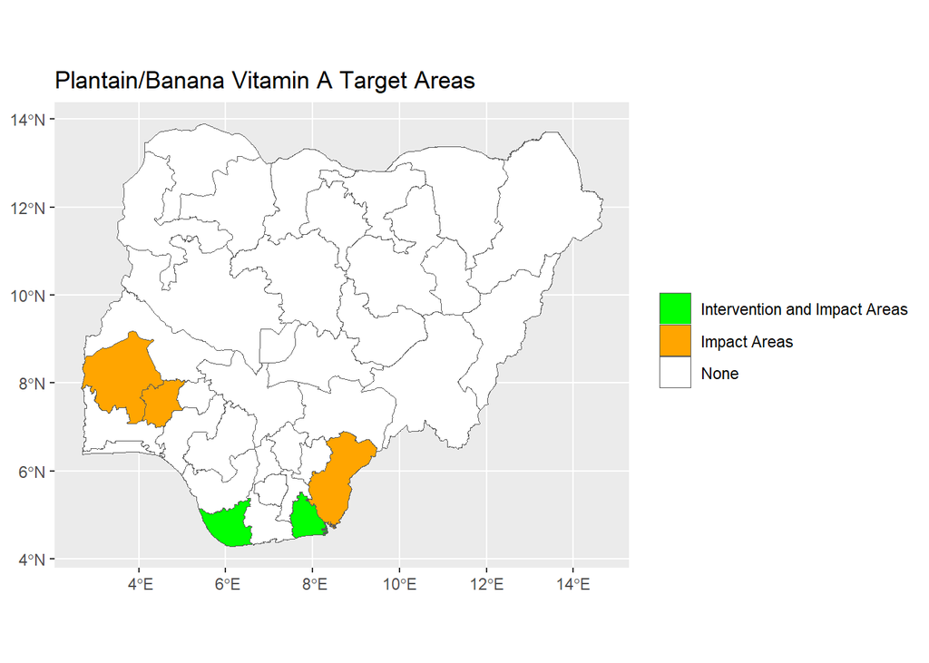

```r
df_plantain_banana_VitA_BPI_areas <- df_plantain_banana_VitA_BPI |> mutate(plantain_banana_BPI_compare = ifelse((
              (Plantain > median_plantain_banana_CI) &
    (plantain_banana_PI > median_plantain_banana_PI) &
                (VitA_I > median_VitA_I)),
  "Intervention and Impact Areas",

 ifelse((
                  (Plantain >= median_plantain_banana_CI) &
        (plantain_banana_PI <= median_plantain_banana_PI) &
                    (VitA_I >= median_VitA_I)),
  "Impact Areas",

ifelse((
                  (Plantain < median_plantain_banana_CI) &
        (plantain_banana_PI > median_plantain_banana_PI) &
                    (VitA_I < median_VitA_I)),
  "Intervention Areas",

  "None"))))  |>
  select(adm1_ref_name, plantain_banana_PI, Plantain, VitA_I, plantain_banana_VitA_BPI, plantain_banana_BPI_compare )


vect_state_geo_plantain_banana_VitA_BPI <- dplyr::left_join(vect_state_geo, df_plantain_banana_VitA_BPI_areas, by = "adm1_ref_name")

ggplot(vect_state_geo_plantain_banana_VitA_BPI) +
  geom_spatvector(aes(fill = plantain_banana_BPI_compare)) +
  scale_fill_manual(
    values = area_colours,    # Custom Colors
    breaks = area_breaks_target) +     # User-defined Breaks & Display Order
  labs(title = "Plantain/Banana Vitamin A Target Areas", fill = "") +
  theme(
    plot.title = element_markdown(),
    legend.title = element_markdown(),
    axis.title = element_blank()
  )
```

### Cassava Vitamin A Target Areas

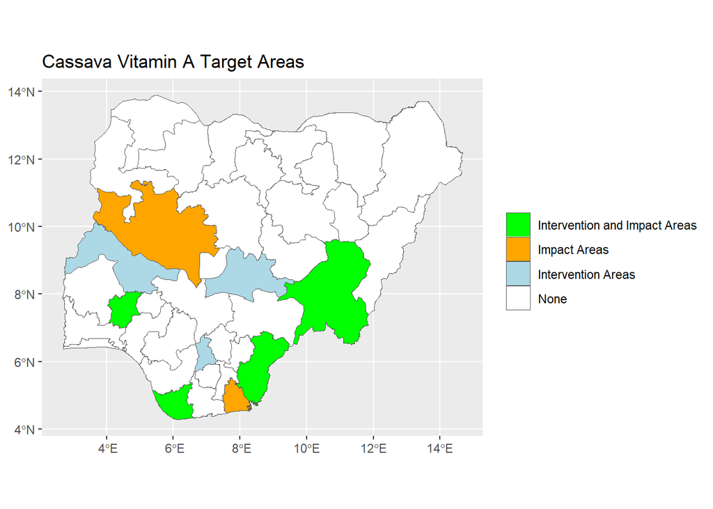

```r
df_cassava_VitA_BPI_areas <- df_cassava_VitA_BPI |> mutate(cassava_BPI_compare = ifelse((
       (Cassava > median_cassava_CI) &
    (cassava_PI > median_cassava_PI) &
        (VitA_I > median_VitA_I)),
  "Intervention and Impact Areas",

 ifelse((
      (Cassava >= median_cassava_CI) &
    (cassava_PI <= median_cassava_PI) &
        (VitA_I >= median_VitA_I)),
  "Impact Areas",

ifelse((
      (Cassava < median_cassava_CI) &
    (cassava_PI > median_cassava_PI) &
        (VitA_I < median_VitA_I)),
  "Intervention Areas",

  "None"))))  |>
  select(adm1_ref_name, cassava_PI, Plantain, VitA_I, cassava_VitA_BPI, cassava_BPI_compare )


vect_state_geo_cassava_VitA_BPI <- dplyr::left_join(vect_state_geo, df_cassava_VitA_BPI_areas, by = "adm1_ref_name")

ggplot(vect_state_geo_cassava_VitA_BPI) +
  geom_spatvector(aes(fill = cassava_BPI_compare)) +
  scale_fill_manual(
    values = area_colours,    # Custom Colors
    breaks = area_breaks_target) +     # User-defined Breaks & Display Order
  labs(title = "Cassava Vitamin A Target Areas", fill = "") +
  theme(
    plot.title = element_markdown(),
    legend.title = element_markdown(),
    axis.title = element_blank()
  )
```

### Cowpea Zinc Target Areas

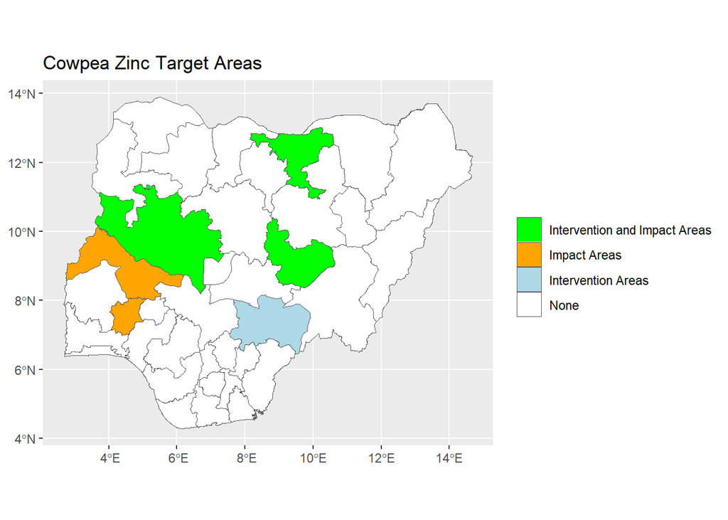

```r
df_cowpea_Zn_BPI_areas <- df_cowpea_Zn_BPI |> mutate(cowpea_BPI_compare = ifelse((
       (Cowpea > median_cowpea_CI) &
    (cowpea_PI > median_cowpea_PI) &
        (Zn_I > median_Zn_I)),
  "Intervention and Impact Areas",

 ifelse((
      (Cowpea >= median_cowpea_CI) &
    (cowpea_PI <= median_cowpea_PI) &
        (Zn_I >= median_Zn_I)),
  "Impact Areas",

ifelse((
      (Cowpea < median_cowpea_CI) &
    (cowpea_PI > median_cowpea_PI) &
        (Zn_I < median_Zn_I)),
  "Intervention Areas",

  "None"))))  |>
  select(adm1_ref_name, cowpea_PI, Plantain, Zn_I, cowpea_Zn_BPI, cowpea_BPI_compare )


vect_state_geo_cowpea_Zn_BPI <- dplyr::left_join(vect_state_geo, df_cowpea_Zn_BPI_areas, by = "adm1_ref_name")

ggplot(vect_state_geo_cowpea_Zn_BPI) +
  geom_spatvector(aes(fill = cowpea_BPI_compare)) +
  scale_fill_manual(
    values = area_colours,    # Custom Colors
    breaks = area_breaks_target) +     # User-defined Breaks & Display Order
  labs(title = "Cowpea Zinc Target Areas", fill = "") +
  theme(
    plot.title = element_markdown(),
    legend.title = element_markdown(),
    axis.title = element_blank()
  )
```

### Cowpea Iron Target Areas

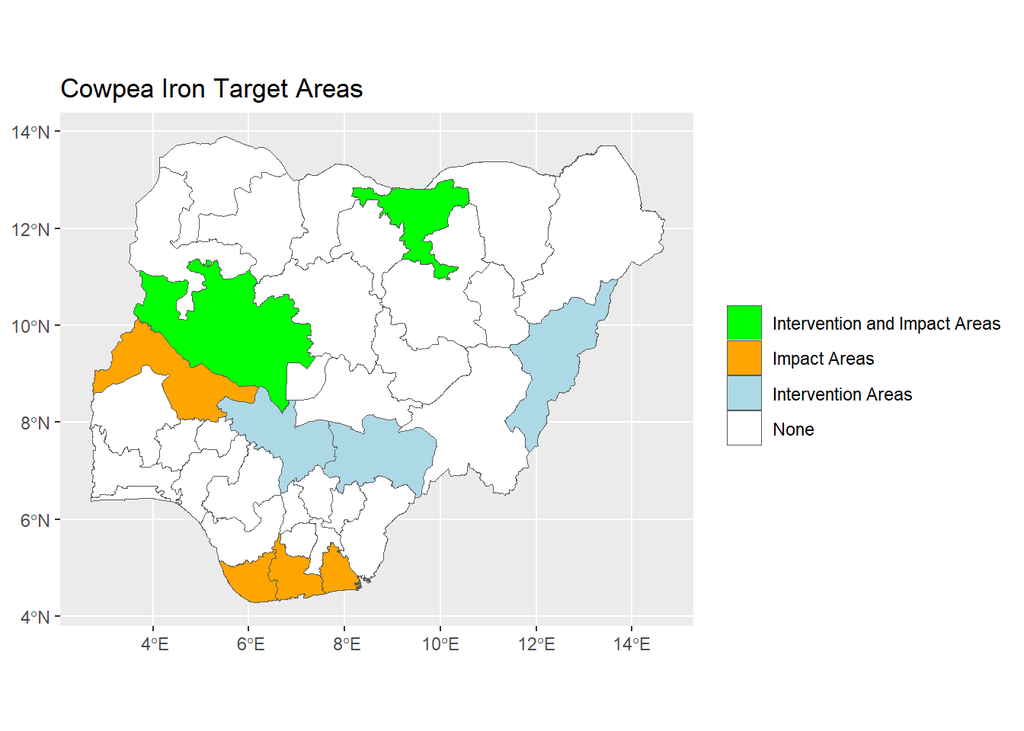

```r
df_cowpea_Fe_BPI_areas <- df_cowpea_Fe_BPI |> mutate(cowpea_BPI_compare = ifelse((
       (Cowpea > median_cowpea_CI) &
    (cowpea_PI > median_cowpea_PI) &
        (Fe_I > median_Fe_I)),
  "Intervention and Impact Areas",

 ifelse((
      (Cowpea >= median_cowpea_CI) &
    (cowpea_PI <= median_cowpea_PI) &
        (Fe_I >= median_Fe_I)),
  "Impact Areas",

ifelse((
      (Cowpea < median_cowpea_CI) &
    (cowpea_PI > median_cowpea_PI) &
        (Fe_I < median_Fe_I)),
  "Intervention Areas",

  "None"))))  |>
  select(adm1_ref_name, cowpea_PI, Plantain, Fe_I, cowpea_Fe_BPI, cowpea_BPI_compare )


vect_state_geo_cowpea_Fe_BPI <- dplyr::left_join(vect_state_geo, df_cowpea_Fe_BPI_areas, by = "adm1_ref_name")

ggplot(vect_state_geo_cowpea_Fe_BPI) +
  geom_spatvector(aes(fill = cowpea_BPI_compare)) +
  scale_fill_manual(
    values = area_colours,    # Custom Colors
    breaks = area_breaks_target) +     # User-defined Breaks & Display Order
  labs(title = "Cowpea Iron Target Areas", fill = "") +
  theme(
    plot.title = element_markdown(),
    legend.title = element_markdown(),
    axis.title = element_blank()
  )
```

### Maize Vitamin A Target Areas

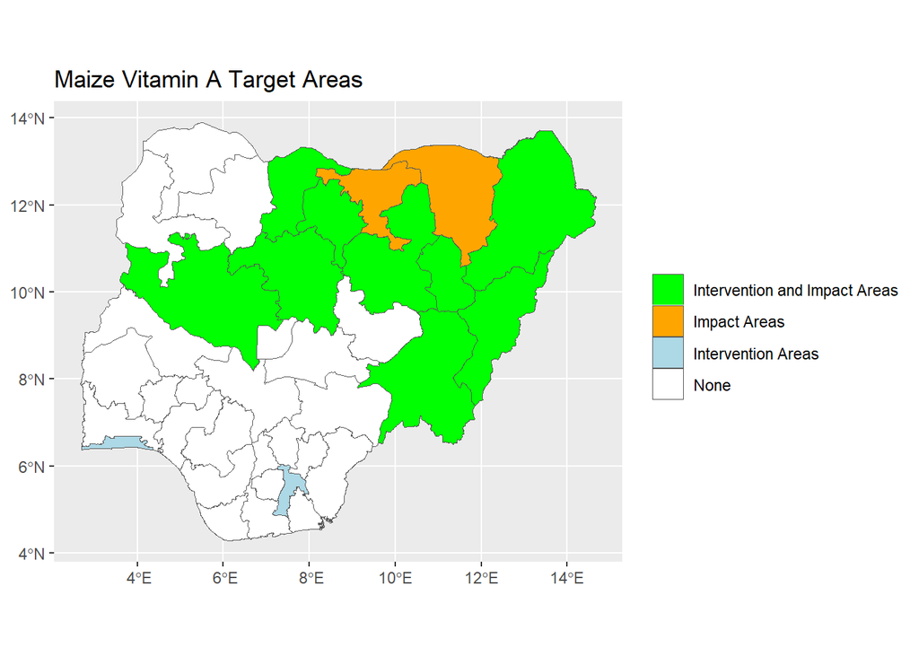

```r
df_maize_VitA_BPI_areas <- df_maize_VitA_BPI |> mutate(maize_BPI_compare = ifelse((
       (Maize > median_maize_CI) &
    (maize_PI > median_maize_PI) &
      (VitA_I > median_VitA_I)),
  "Intervention and Impact Areas",

 ifelse((
    (Maize >= median_maize_CI) &
    (maize_PI <= median_maize_PI) &
      (VitA_I >= median_VitA_I)),
  "Impact Areas",

ifelse((
    (Maize < median_maize_CI) &
    (maize_PI > median_maize_PI) &
      (VitA_I < median_VitA_I)),
  "Intervention Areas",

  "None"))))  |>
  select(adm1_ref_name, maize_PI, Plantain, VitA_I, maize_VitA_BPI, maize_BPI_compare )


vect_state_geo_maize_VitA_BPI <- dplyr::left_join(vect_state_geo, df_maize_VitA_BPI_areas, by = "adm1_ref_name")

ggplot(vect_state_geo_maize_VitA_BPI) +
  geom_spatvector(aes(fill = maize_BPI_compare)) +
  scale_fill_manual(
    values = area_colours,    # Custom Colors
    breaks = area_breaks_target) +     # User-defined Breaks & Display Order
  labs(title = "Maize Vitamin A Target Areas", fill = "") +
  theme(
    plot.title = element_markdown(),
    legend.title = element_markdown(),
    axis.title = element_blank()
  )
```

### Maize Zinc Target Areas

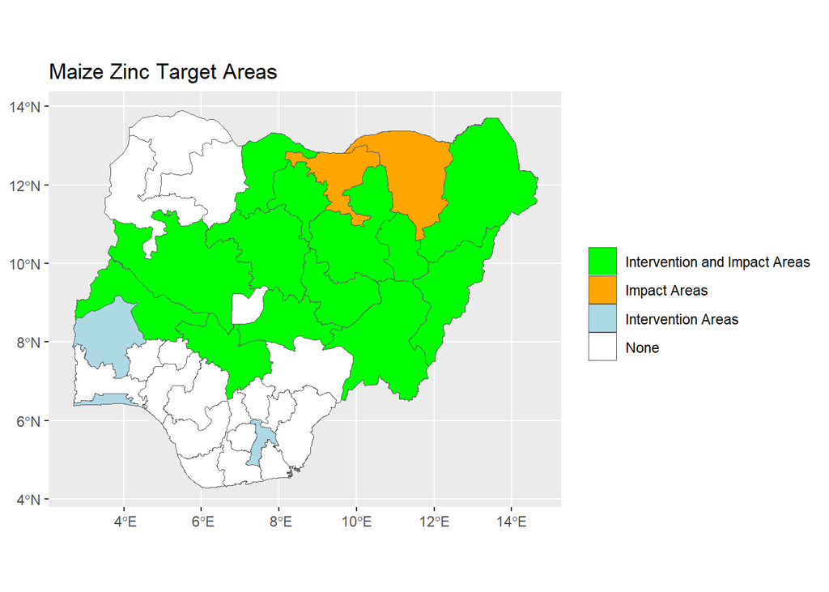

```r
df_maize_Zn_BPI_areas <- df_maize_Zn_BPI |> mutate(maize_BPI_compare = ifelse((
       (Maize > median_maize_CI) &
    (maize_PI > median_maize_PI) &
        (Zn_I > median_Zn_I)),
  "Intervention and Impact Areas",

 ifelse((
      (Maize >= median_maize_CI) &
    (maize_PI <= median_maize_PI) &
        (Zn_I >= median_Zn_I)),
  "Impact Areas",

ifelse((
      (Maize < median_maize_CI) &
    (maize_PI > median_maize_PI) &
        (Zn_I < median_Zn_I)),
  "Intervention Areas",

  "None"))))  |>
  select(adm1_ref_name, maize_PI, Plantain, Zn_I, maize_Zn_BPI, maize_BPI_compare )


vect_state_geo_maize_Zn_BPI <- dplyr::left_join(vect_state_geo, df_maize_Zn_BPI_areas, by = "adm1_ref_name")

ggplot(vect_state_geo_maize_Zn_BPI) +
  geom_spatvector(aes(fill = maize_BPI_compare)) +
  scale_fill_manual(
    values = area_colours,    # Custom Colors
    breaks = area_breaks_target) +     # User-defined Breaks & Display Order
  labs(title = "Maize Zinc Target Areas", fill = "") +
  theme(
    plot.title = element_markdown(),
    legend.title = element_markdown(),
    axis.title = element_blank()
  )
```

### Rice Zinc Target Areas

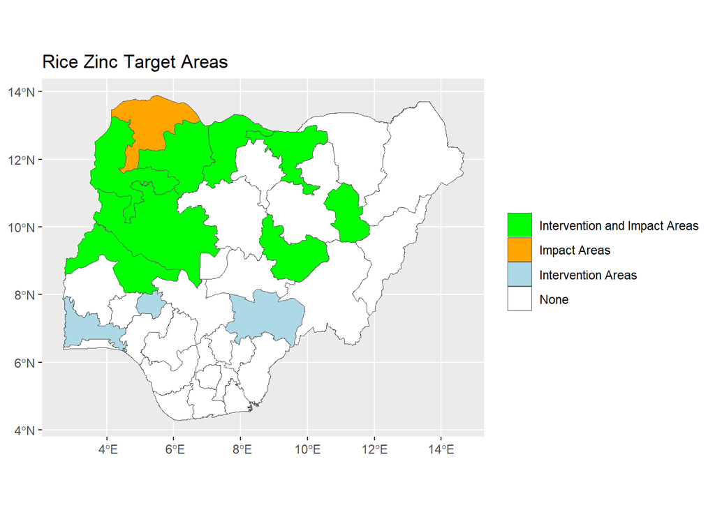

```r
df_rice_Zn_BPI_areas <- df_rice_Zn_BPI |> mutate(rice_BPI_compare = ifelse((
       (Rice > median_rice_CI) &
    (rice_PI > median_rice_PI) &
        (Zn_I > median_Zn_I)),
  "Intervention and Impact Areas",

 ifelse((
      (Rice >= median_rice_CI) &
    (rice_PI <= median_rice_PI) &
        (Zn_I >= median_Zn_I)),
  "Impact Areas",

ifelse((
      (Rice < median_rice_CI) &
    (rice_PI > median_rice_PI) &
        (Zn_I < median_Zn_I)),
  "Intervention Areas",

  "None"))))  |>
  select(adm1_ref_name, rice_PI, Plantain, Zn_I, rice_Zn_BPI, rice_BPI_compare )


vect_state_geo_rice_Zn_BPI <- dplyr::left_join(vect_state_geo, df_rice_Zn_BPI_areas, by = "adm1_ref_name")

ggplot(vect_state_geo_rice_Zn_BPI) +
  geom_spatvector(aes(fill = rice_BPI_compare)) +
  scale_fill_manual(
    values = area_colours,    # Custom Colors
    breaks = area_breaks_target) +     # User-defined Breaks & Display Order
  labs(title = "Rice Zinc Target Areas", fill = "") +
  theme(
    plot.title = element_markdown(),
    legend.title = element_markdown(),
    axis.title = element_blank()
  )
```

### Sorghum Zinc Target Areas

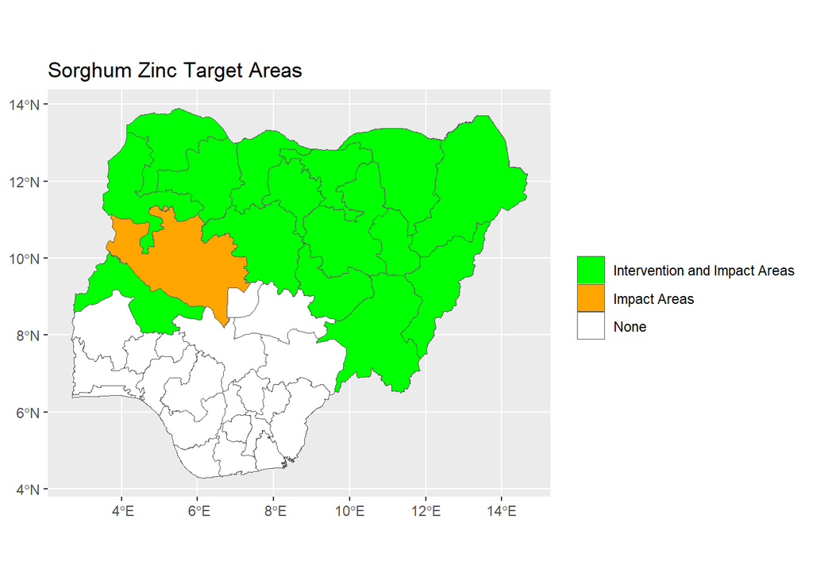

```r
df_sorghum_Zn_BPI_areas <- df_sorghum_Zn_BPI |> mutate(sorghum_BPI_compare = ifelse((
       (Sorghum > median_sorghum_CI) &
    (sorghum_PI > median_sorghum_PI) &
        (Zn_I > median_Zn_I)),
  "Intervention and Impact Areas",

 ifelse((
      (Sorghum >= median_sorghum_CI) &
    (sorghum_PI <= median_sorghum_PI) &
        (Zn_I >= median_Zn_I)),
  "Impact Areas",

ifelse((
      (Sorghum < median_sorghum_CI) &
    (sorghum_PI > median_sorghum_PI) &
        (Zn_I < median_Zn_I)),
  "Intervention Areas",

  "None"))))  |>
  select(adm1_ref_name, sorghum_PI, Plantain, Zn_I, sorghum_Zn_BPI, sorghum_BPI_compare )


vect_state_geo_sorghum_Zn_BPI <- dplyr::left_join(vect_state_geo, df_sorghum_Zn_BPI_areas, by = "adm1_ref_name")

ggplot(vect_state_geo_sorghum_Zn_BPI) +
  geom_spatvector(aes(fill = sorghum_BPI_compare)) +
  scale_fill_manual(
    values = area_colours,    # Custom Colors
    breaks = area_breaks_target) +     # User-defined Breaks & Display Order
  labs(title = "Sorghum Zinc Target Areas", fill = "") +
  theme(
    plot.title = element_markdown(),
    legend.title = element_markdown(),
    axis.title = element_blank()
  )
```

### Sorghum Iron Target Areas

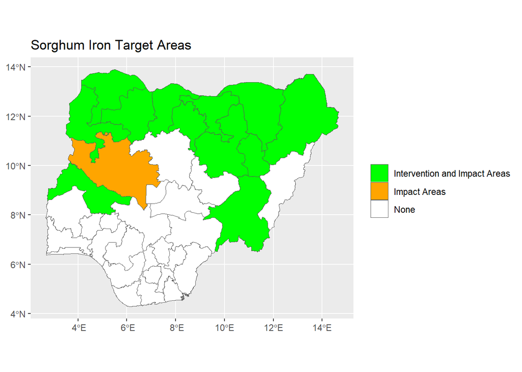

```r
df_sorghum_Fe_BPI_areas <- df_sorghum_Fe_BPI |> mutate(sorghum_BPI_compare = ifelse((
       (Sorghum > median_sorghum_CI) &
    (sorghum_PI > median_sorghum_PI) &
        (Fe_I > median_Fe_I)),
  "Intervention and Impact Areas",

 ifelse((
      (Sorghum >= median_sorghum_CI) &
    (sorghum_PI <= median_sorghum_PI) &
        (Fe_I >= median_Fe_I)),
  "Impact Areas",

ifelse((
      (Sorghum < median_sorghum_CI) &
    (sorghum_PI > median_sorghum_PI) &
        (Fe_I < median_Fe_I)),
  "Intervention Areas",

  "None"))))  |>
  select(adm1_ref_name, sorghum_PI, Plantain, Fe_I, sorghum_Fe_BPI, sorghum_BPI_compare )


vect_state_geo_sorghum_Fe_BPI <- dplyr::left_join(vect_state_geo, df_sorghum_Fe_BPI_areas, by = "adm1_ref_name")

ggplot(vect_state_geo_sorghum_Fe_BPI) +
  geom_spatvector(aes(fill = sorghum_BPI_compare)) +
  scale_fill_manual(
    values = area_colours,    # Custom Colors
    breaks = area_breaks_target) +     # User-defined Breaks & Display Order
  labs(title = "Sorghum Iron Target Areas", fill = "") +
  theme(
    plot.title = element_markdown(),
    legend.title = element_markdown(),
    axis.title = element_blank()
  )
```

### Sweet Potato Vitamin A Target Areas

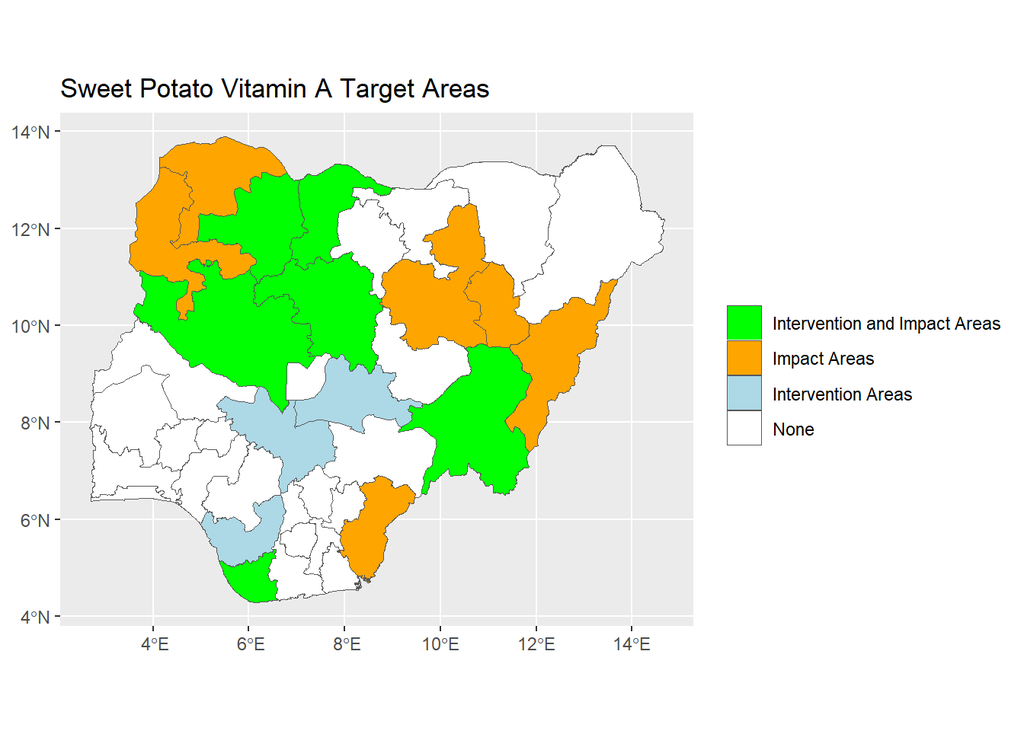

```r
df_spot_VitA_BPI_areas <- df_spot_VitA_BPI |> mutate(spot_BPI_compare = ifelse((
  (Sweet.potato > median_spot_CI) &
       (spot_PI > median_spot_PI) &
        (VitA_I > median_VitA_I)),
  "Intervention and Impact Areas",

 ifelse((
  (Sweet.potato >= median_spot_CI) &
       (spot_PI <= median_spot_PI) &
        (VitA_I >= median_VitA_I)),
  "Impact Areas",

ifelse((
  (Sweet.potato < median_spot_CI) &
       (spot_PI > median_spot_PI) &
        (VitA_I < median_VitA_I)),
  "Intervention Areas",

  "None"))))  |>
  select(adm1_ref_name, spot_PI, Sweet.potato, VitA_I, spot_VitA_BPI, spot_BPI_compare )


vect_state_geo_spot_VitA_BPI <- dplyr::left_join(vect_state_geo, df_spot_VitA_BPI_areas, by = "adm1_ref_name")

ggplot(vect_state_geo_spot_VitA_BPI) +
  geom_spatvector(aes(fill = spot_BPI_compare)) +
  scale_fill_manual(
    values = area_colours,    # Custom Colors
    breaks = area_breaks_target) +     # User-defined Breaks & Display Order
  labs(title = "Sweet Potato Vitamin A Target Areas", fill = "") +
  theme(
    plot.title = element_markdown(),
    legend.title = element_markdown(),
    axis.title = element_blank()
  )
```

## Weighted Biofortification Priority Indices

The Biofortification Priority Indices were designed to be unit less, so as to reduce any bias towards countries that had a larger population or area - factors that would affect the consumption and production indices if they were measured in units of total consumption or harvested areas.

Nevertheless, there may be reasons for policy makers to require the BPI to be weighted to reflect opportunities for investment where large populations can be reached or where there is a large production that merits investing in breeding efforts, as well as the seed system associated with the diffusion of bioforitified varieties of staple crops (Asare-Marfo et al. 2013).

$$BPI_w = BPI_r * A * 100 \tag{14}$$

Where:

- $BPI_w$ is the weighted BPI
- $BPI_r$ is the rescaled BPI
- $A$ is the weight

$$A = ({P_{ij} / {P_j}) * 100} \tag{15}$$

or

$$A = (({PopCH_{i}} + {PopWRA_{i}) / ({PopCH} + {PopWRA})) * 100} \tag{16}$$

Where:

- $P_{ij}$ is the harvest area of crop $j$ in state $i$
- $P_j$ is the national harvest area of crop $j$
- $PopCH_{i}$ is the population of children between 6-59 months in state $i$
- $PopWRA_{i}$ is the population of women of reproductive age in state $i$
- $PopCH$ is the national population of children between 6-59 months
- $PopWRA$ is the national population of women of reproductive age

### Plantain/Banana Vitamin A BPI weighted by state share of national harvest area

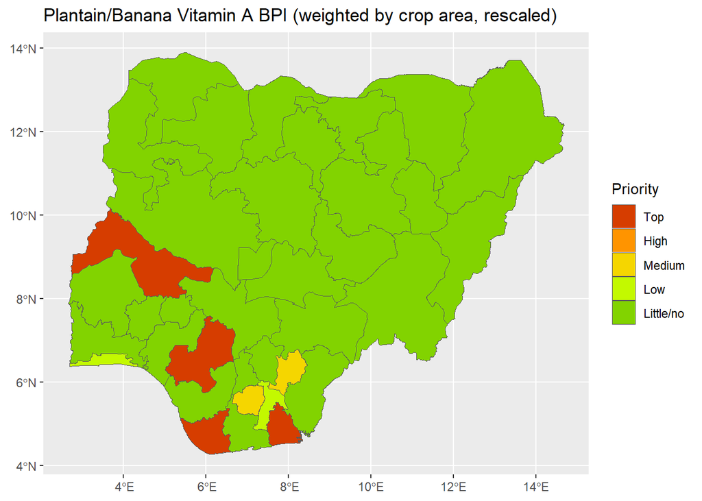

```r
df_plantain_banana_national_share <- read.csv("tab_data/plantain_banana_area_national_share_2024.csv")

df_plantain_banana_VitA_BPI_weighted <- left_join(df_plantain_banana_VitA_BPI_rescale, df_plantain_banana_national_share, by = "adm1_ref_name") |>
  mutate( plantain_banana_VitA_BPI_weight_share = (plantain_banana_VitA_BPI_rescale * plantain_banana_Area_2024_pc))

df_plantain_banana_VitA_BPI_weighted_normalised <- as.data.frame(lapply(select(df_plantain_banana_VitA_BPI_weighted, plantain_banana_VitA_BPI_weight_share ), minMax)) |>
  mutate(plantain_banana_VitA_BPI_weight_share_rescale = (plantain_banana_VitA_BPI_weight_share * 100))

df_plantain_banana_VitA_BPI_weighted_rescale <- bind_cols(select(df_plantain_banana_VitA_BPI_weighted, adm1_ref_name), df_plantain_banana_VitA_BPI_weighted_normalised)

vect_state_geo_plantain_banana_VitA_BPI_weighted_rescale <- dplyr::left_join(vect_state_geo, df_plantain_banana_VitA_BPI_weighted_rescale, by = "adm1_ref_name")

ggplot(vect_state_geo_plantain_banana_VitA_BPI_weighted_rescale) +
  geom_spatvector(aes(fill = plantain_banana_VitA_BPI_weight_share_rescale)) +
  scale_fill_stepsn(
    colors = colours_priority,
    values = scales::rescale(breaks_priority),
    breaks = breaks_priority,
    limits = c(0, 100),
    na.value = "grey",
    labels = labels_priority
  ) +
  guides(fill = guide_legend(reverse=T)) +
  labs(title = "Plantain/Banana Vitamin A BPI (weighted by crop area, rescaled)", fill = "Priority") +
  theme(
    plot.title = element_markdown(),
    legend.title = element_markdown(),
    axis.title = element_blank()
  )
```

### Cassava Vitamin A BPI weighted by state share of national harvest area

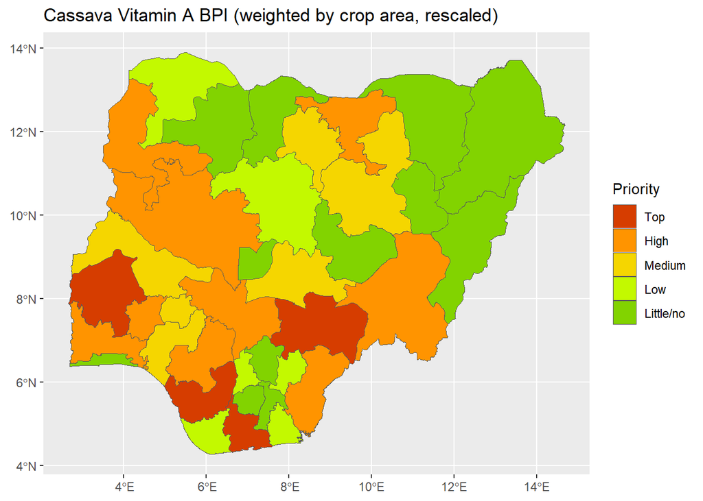

```r
df_cassava_national_share <- read.csv("tab_data/cassava_area_national_share_2022.csv")

df_cassava_VitA_BPI_weighted <- left_join(df_cassava_VitA_BPI_rescale, df_cassava_national_share, by = "adm1_ref_name") |>
  mutate( cassava_VitA_BPI_weight_share = (cassava_VitA_BPI_rescale * cassava_Area_2022_pc))

df_cassava_VitA_BPI_weighted_normalised <- as.data.frame(lapply(select(df_cassava_VitA_BPI_weighted, cassava_VitA_BPI_weight_share ), minMax)) |>
  mutate(cassava_VitA_BPI_weight_share_rescale = (cassava_VitA_BPI_weight_share * 100))

df_cassava_VitA_BPI_weighted_rescale <- bind_cols(select(df_cassava_VitA_BPI_weighted, adm1_ref_name), df_cassava_VitA_BPI_weighted_normalised)

vect_state_geo_cassava_VitA_BPI_weighted_rescale <- dplyr::left_join(vect_state_geo, df_cassava_VitA_BPI_weighted_rescale, by = "adm1_ref_name")

ggplot(vect_state_geo_cassava_VitA_BPI_weighted_rescale) +
  geom_spatvector(aes(fill = cassava_VitA_BPI_weight_share_rescale)) +
  scale_fill_stepsn(
    colors = colours_priority,
    values = scales::rescale(breaks_priority),
    breaks = breaks_priority,
    limits = c(0, 100),
    na.value = "grey",
    labels = labels_priority
  ) +
  guides(fill = guide_legend(reverse=T)) +
  labs(title = "Cassava Vitamin A BPI (weighted by crop area, rescaled)", fill = "Priority") +
  theme(
    plot.title = element_markdown(),
    legend.title = element_markdown(),
    axis.title = element_blank()
  )
```

### Cowpea Zinc BPI weighted by state share of national harvest area

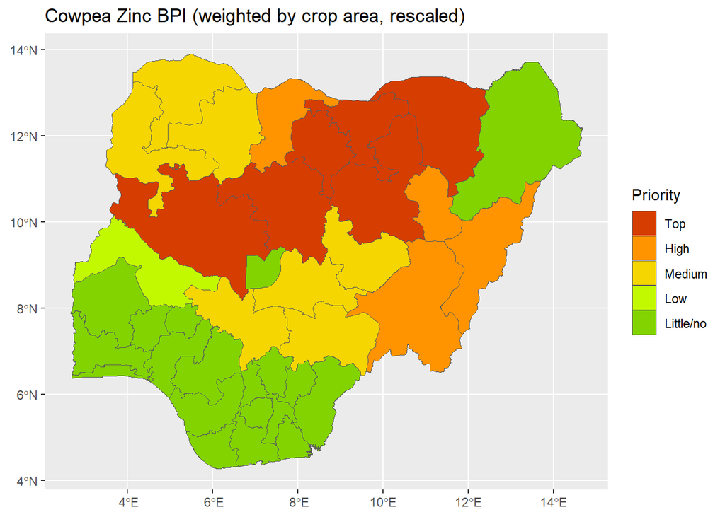

```r
df_cowpea_national_share <- read.csv("tab_data/cowpea_area_national_share_2022.csv")

df_cowpea_Zn_BPI_weighted <- left_join(df_cowpea_Zn_BPI_rescale, df_cowpea_national_share, by = "adm1_ref_name") |>
  mutate( cowpea_Zn_BPI_weight_share = (cowpea_Zn_BPI_rescale * cowpea_Area_2022_pc))

df_cowpea_Zn_BPI_weighted_normalised <- as.data.frame(lapply(select(df_cowpea_Zn_BPI_weighted, cowpea_Zn_BPI_weight_share ), minMax)) |>
  mutate(cowpea_Zn_BPI_weight_share_rescale = (cowpea_Zn_BPI_weight_share * 100))

df_cowpea_Zn_BPI_weighted_rescale <- bind_cols(select(df_cowpea_Zn_BPI_weighted, adm1_ref_name), df_cowpea_Zn_BPI_weighted_normalised)

vect_state_geo_cowpea_Zn_BPI_weighted_rescale <- dplyr::left_join(vect_state_geo, df_cowpea_Zn_BPI_weighted_rescale, by = "adm1_ref_name")

ggplot(vect_state_geo_cowpea_Zn_BPI_weighted_rescale) +
  geom_spatvector(aes(fill = cowpea_Zn_BPI_weight_share_rescale)) +
  scale_fill_stepsn(
    colors = colours_priority,
    values = scales::rescale(breaks_priority),
    breaks = breaks_priority,
    limits = c(0, 100),
    na.value = "grey",
    labels = labels_priority
  ) +
  guides(fill = guide_legend(reverse=T)) +
  labs(title = "Cowpea Zinc BPI (weighted by crop area, rescaled)", fill = "Priority") +
  theme(
    plot.title = element_markdown(),
    legend.title = element_markdown(),
    axis.title = element_blank()
  )
```

### Cowpea Iron BPI weighted by state share of national harvest area

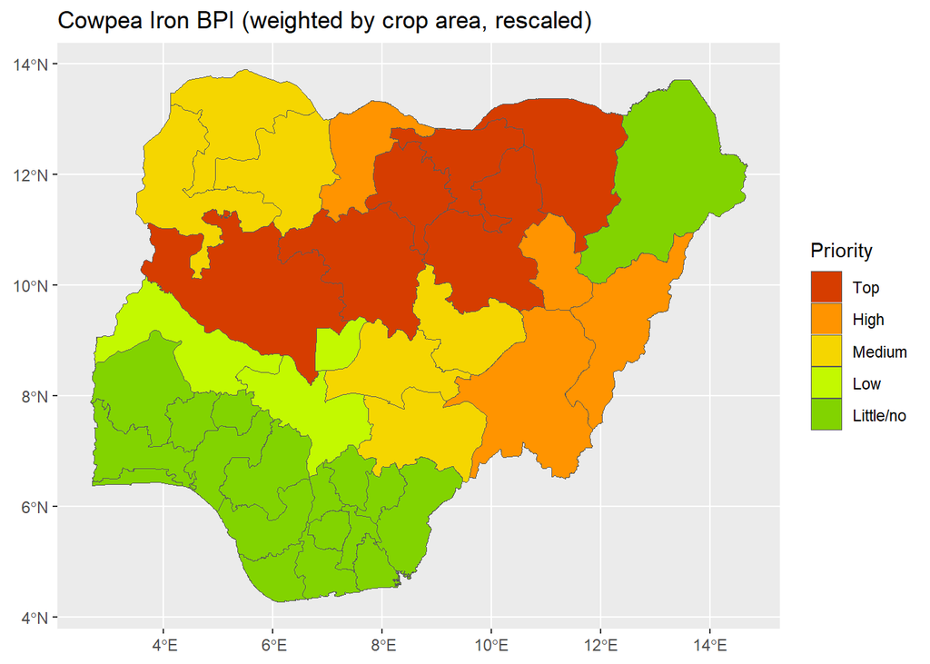

```r
df_cowpea_national_share <- read.csv("tab_data/cowpea_area_national_share_2022.csv")

df_cowpea_Fe_BPI_weighted <- left_join(df_cowpea_Fe_BPI_rescale, df_cowpea_national_share, by = "adm1_ref_name") |>
  mutate( cowpea_Fe_BPI_weight_share = (cowpea_Fe_BPI_rescale * cowpea_Area_2022_pc))

df_cowpea_Fe_BPI_weighted_normalised <- as.data.frame(lapply(select(df_cowpea_Fe_BPI_weighted, cowpea_Fe_BPI_weight_share ), minMax)) |>
  mutate(cowpea_Fe_BPI_weight_share_rescale = (cowpea_Fe_BPI_weight_share * 100))

df_cowpea_Fe_BPI_weighted_rescale <- bind_cols(select(df_cowpea_Fe_BPI_weighted, adm1_ref_name), df_cowpea_Fe_BPI_weighted_normalised)

vect_state_geo_cowpea_Fe_BPI_weighted_rescale <- dplyr::left_join(vect_state_geo, df_cowpea_Fe_BPI_weighted_rescale, by = "adm1_ref_name")

ggplot(vect_state_geo_cowpea_Fe_BPI_weighted_rescale) +
  geom_spatvector(aes(fill = cowpea_Fe_BPI_weight_share_rescale)) +
  scale_fill_stepsn(
    colors = colours_priority,
    values = scales::rescale(breaks_priority),
    breaks = breaks_priority,
    limits = c(0, 100),
    na.value = "grey",
    labels = labels_priority
  ) +
  guides(fill = guide_legend(reverse=T)) +
  labs(title = "Cowpea Iron BPI (weighted by crop area, rescaled)", fill = "Priority") +
  theme(
    plot.title = element_markdown(),
    legend.title = element_markdown(),
    axis.title = element_blank()
  )
```

### Maize Vitamin A BPI weighted by state share of national harvest area

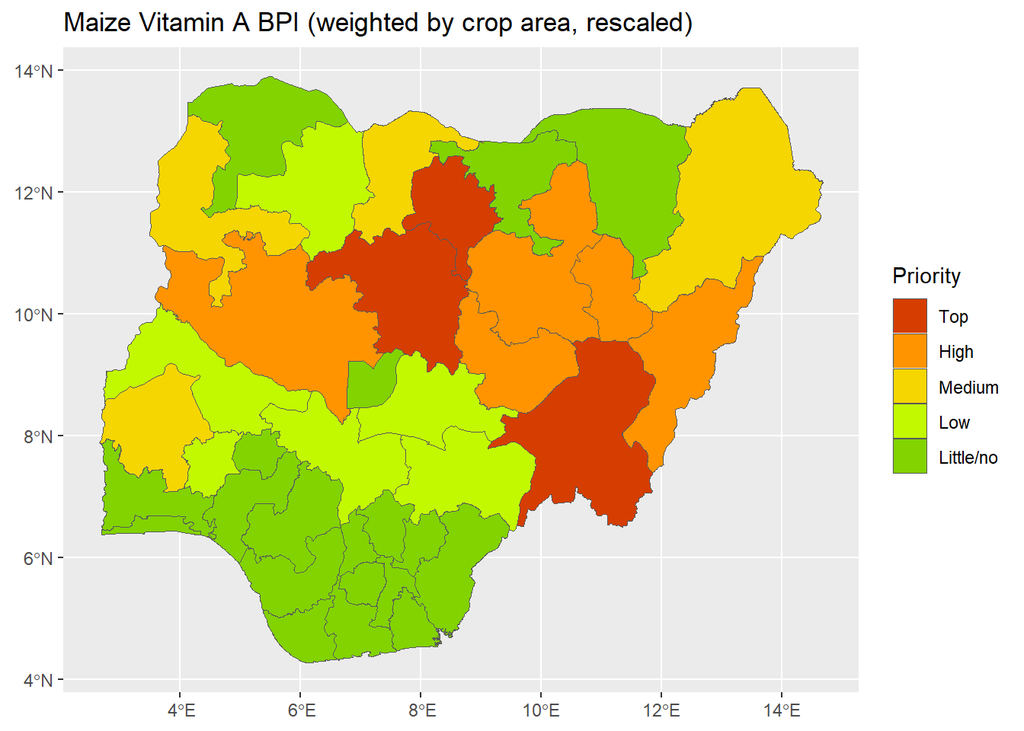

```r
df_maize_national_share <- read.csv("tab_data/maize_area_national_share_2022.csv")

df_maize_VitA_BPI_weighted <- left_join(df_maize_VitA_BPI_rescale, df_maize_national_share, by = "adm1_ref_name") |>
  mutate( maize_VitA_BPI_weight_share = (maize_VitA_BPI_rescale * maize_Area_2022_pc))

df_maize_VitA_BPI_weighted_normalised <- as.data.frame(lapply(select(df_maize_VitA_BPI_weighted, maize_VitA_BPI_weight_share ), minMax)) |>
  mutate(maize_VitA_BPI_weight_share_rescale = (maize_VitA_BPI_weight_share * 100))

df_maize_VitA_BPI_weighted_rescale <- bind_cols(select(df_maize_VitA_BPI_weighted, adm1_ref_name), df_maize_VitA_BPI_weighted_normalised)

vect_state_geo_maize_VitA_BPI_weighted_rescale <- dplyr::left_join(vect_state_geo, df_maize_VitA_BPI_weighted_rescale, by = "adm1_ref_name")

ggplot(vect_state_geo_maize_VitA_BPI_weighted_rescale) +
  geom_spatvector(aes(fill = maize_VitA_BPI_weight_share_rescale)) +
  scale_fill_stepsn(
    colors = colours_priority,
    values = scales::rescale(breaks_priority),
    breaks = breaks_priority,
    limits = c(0, 100),
    na.value = "grey",
    labels = labels_priority
  ) +
  guides(fill = guide_legend(reverse=T)) +
  labs(title = "Maize Vitamin A BPI (weighted by crop area, rescaled)", fill = "Priority") +
  theme(
    plot.title = element_markdown(),
    legend.title = element_markdown(),
    axis.title = element_blank()
  )
```

### Maize Zinc BPI weighted by state share of national harvest area

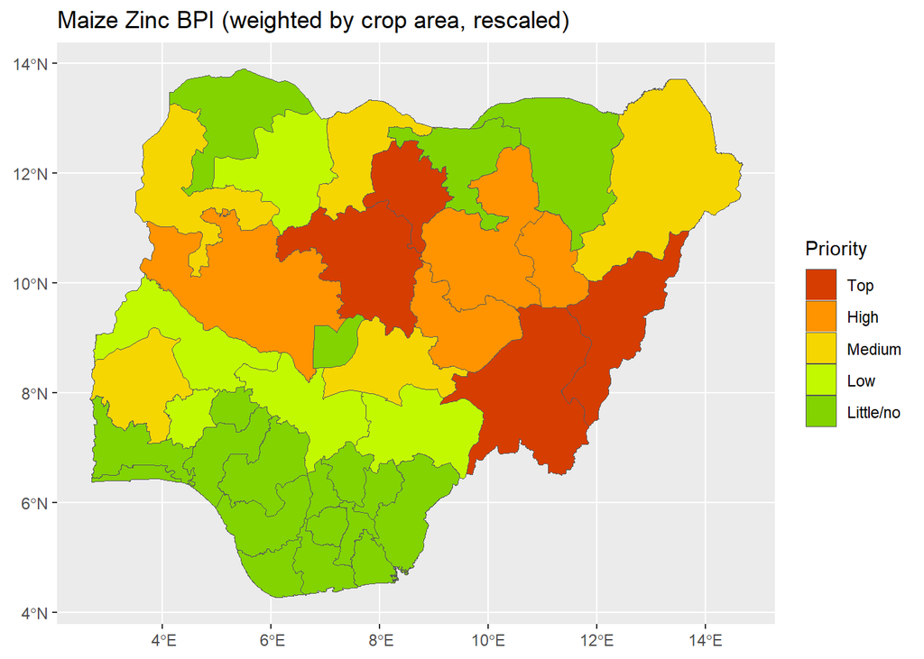

```r
df_maize_national_share <- read.csv("tab_data/maize_area_national_share_2022.csv")

df_maize_Zn_BPI_weighted <- left_join(df_maize_Zn_BPI_rescale, df_maize_national_share, by = "adm1_ref_name") |>
  mutate( maize_Zn_BPI_weight_share = (maize_Zn_BPI_rescale * maize_Area_2022_pc))

df_maize_Zn_BPI_weighted_normalised <- as.data.frame(lapply(select(df_maize_Zn_BPI_weighted, maize_Zn_BPI_weight_share ), minMax)) |>
  mutate(maize_Zn_BPI_weight_share_rescale = (maize_Zn_BPI_weight_share * 100))

df_maize_Zn_BPI_weighted_rescale <- bind_cols(select(df_maize_Zn_BPI_weighted, adm1_ref_name), df_maize_Zn_BPI_weighted_normalised)

vect_state_geo_maize_Zn_BPI_weighted_rescale <- dplyr::left_join(vect_state_geo, df_maize_Zn_BPI_weighted_rescale, by = "adm1_ref_name")

ggplot(vect_state_geo_maize_Zn_BPI_weighted_rescale) +
  geom_spatvector(aes(fill = maize_Zn_BPI_weight_share_rescale)) +
  scale_fill_stepsn(
    colors = colours_priority,
    values = scales::rescale(breaks_priority),
    breaks = breaks_priority,
    limits = c(0, 100),
    na.value = "grey",
    labels = labels_priority
  ) +
  guides(fill = guide_legend(reverse=T)) +
  labs(title = "Maize Zinc BPI (weighted by crop area, rescaled)", fill = "Priority") +
  theme(
    plot.title = element_markdown(),
    legend.title = element_markdown(),
    axis.title = element_blank()
  )
```

### Rice Zinc BPI weighted by state share of national harvest area

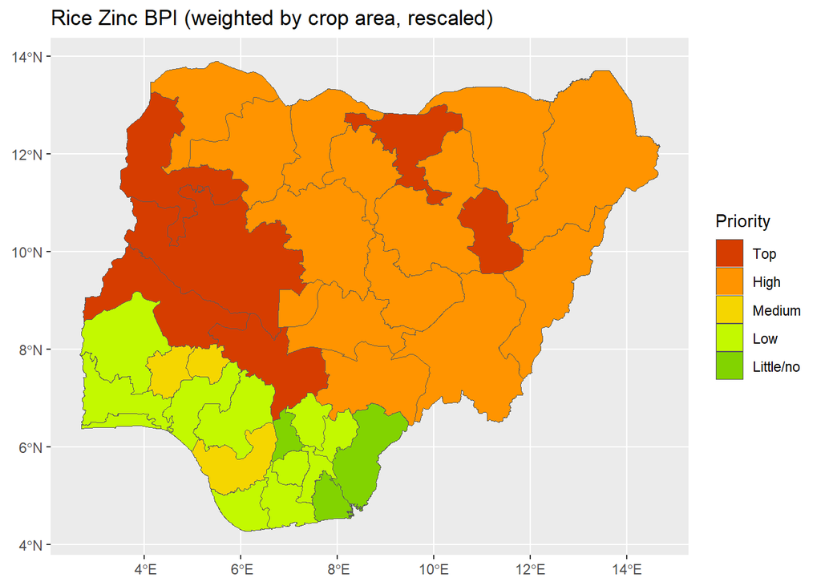

```r
df_rice_national_share <- read.csv("tab_data/rice_area_national_share_2024.csv")

df_rice_Zn_BPI_weighted <- left_join(df_rice_Zn_BPI_rescale, df_rice_national_share, by = "adm1_ref_name") |>
  mutate( rice_Zn_BPI_weight_share = (rice_Zn_BPI_rescale * rice_Area_2024_pc))

df_rice_Zn_BPI_weighted_normalised <- as.data.frame(lapply(select(df_rice_Zn_BPI_weighted, rice_Zn_BPI_weight_share ), minMax)) |>
  mutate(rice_Zn_BPI_weight_share_rescale = (rice_Zn_BPI_weight_share * 100))

df_rice_Zn_BPI_weighted_rescale <- bind_cols(select(df_rice_Zn_BPI_weighted, adm1_ref_name), df_rice_Zn_BPI_weighted_normalised)

vect_state_geo_rice_Zn_BPI_weighted_rescale <- dplyr::left_join(vect_state_geo, df_rice_Zn_BPI_weighted_rescale, by = "adm1_ref_name")

ggplot(vect_state_geo_rice_Zn_BPI_weighted_rescale) +
  geom_spatvector(aes(fill = rice_Zn_BPI_weight_share_rescale)) +
  scale_fill_stepsn(
    colors = colours_priority,
    values = scales::rescale(breaks_priority),
    breaks = breaks_priority,
    limits = c(0, 100),
    na.value = "grey",
    labels = labels_priority
  ) +
  guides(fill = guide_legend(reverse=T)) +
  labs(title = "Rice Zinc BPI (weighted by crop area, rescaled)", fill = "Priority") +
  theme(
    plot.title = element_markdown(),
    legend.title = element_markdown(),
    axis.title = element_blank()
  )
```

### Sorghum Zinc BPI weighted by state share of national harvest area

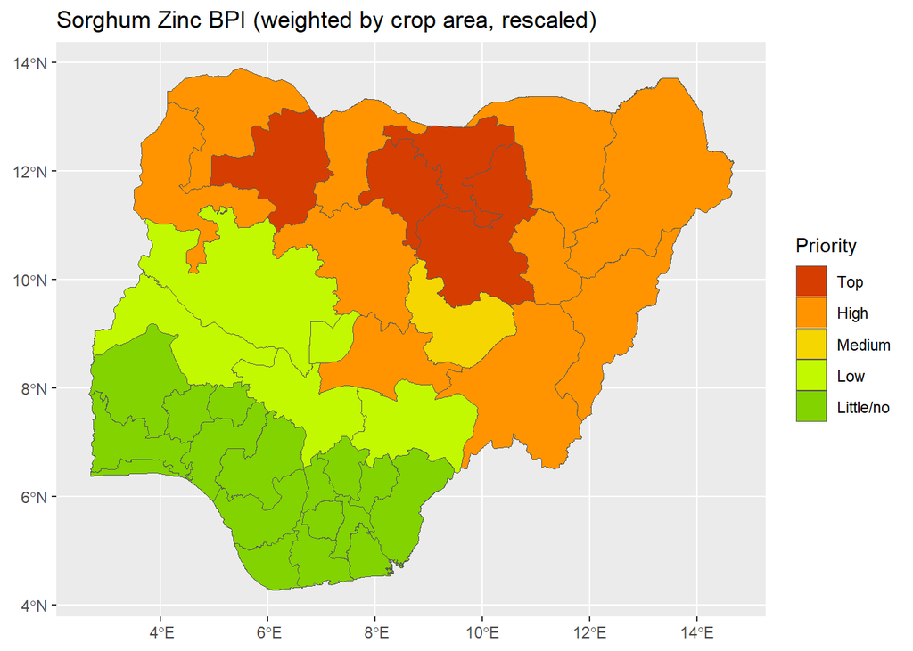

```r
df_sorghum_national_share <- read.csv("tab_data/sorghum_area_national_share_2024.csv")

df_sorghum_Zn_BPI_weighted <- left_join(df_sorghum_Zn_BPI_rescale, df_sorghum_national_share, by = "adm1_ref_name") |>
  mutate( sorghum_Zn_BPI_weight_share = (sorghum_Zn_BPI_rescale * sorghum_Area_2024_pc))

df_sorghum_Zn_BPI_weighted_normalised <- as.data.frame(lapply(select(df_sorghum_Zn_BPI_weighted, sorghum_Zn_BPI_weight_share ), minMax)) |>
  mutate(sorghum_Zn_BPI_weight_share_rescale = (sorghum_Zn_BPI_weight_share * 100))

df_sorghum_Zn_BPI_weighted_rescale <- bind_cols(select(df_sorghum_Zn_BPI_weighted, adm1_ref_name), df_sorghum_Zn_BPI_weighted_normalised)

vect_state_geo_sorghum_Zn_BPI_weighted_rescale <- dplyr::left_join(vect_state_geo, df_sorghum_Zn_BPI_weighted_rescale, by = "adm1_ref_name")

ggplot(vect_state_geo_sorghum_Zn_BPI_weighted_rescale) +
  geom_spatvector(aes(fill = sorghum_Zn_BPI_weight_share_rescale)) +
  scale_fill_stepsn(
    colors = colours_priority,
    values = scales::rescale(breaks_priority),
    breaks = breaks_priority,
    limits = c(0, 100),
    na.value = "grey",
    labels = labels_priority
  ) +
  guides(fill = guide_legend(reverse=T)) +
  labs(title = "Sorghum Zinc BPI (weighted by crop area, rescaled)", fill = "Priority") +
  theme(
    plot.title = element_markdown(),
    legend.title = element_markdown(),
    axis.title = element_blank()
  )
```

### Sorghum Iron BPI weighted by state share of national harvest area

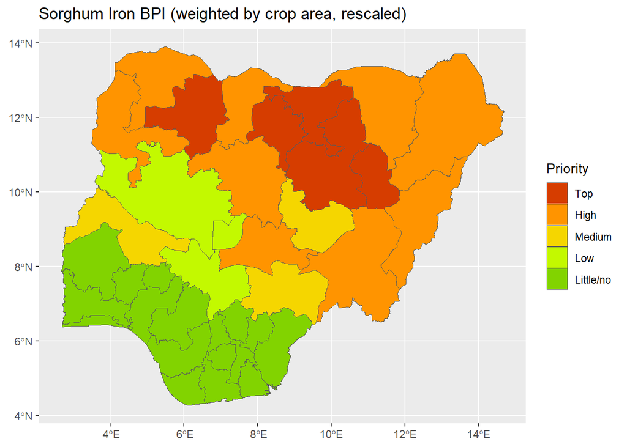

```r
df_sorghum_national_share <- read.csv("tab_data/sorghum_area_national_share_2024.csv")

df_sorghum_Fe_BPI_weighted <- left_join(df_sorghum_Fe_BPI_rescale, df_sorghum_national_share, by = "adm1_ref_name") |>
  mutate( sorghum_Fe_BPI_weight_share = (sorghum_Fe_BPI_rescale * sorghum_Area_2024_pc))

df_sorghum_Fe_BPI_weighted_normalised <- as.data.frame(lapply(select(df_sorghum_Fe_BPI_weighted, sorghum_Fe_BPI_weight_share ), minMax)) |>
  mutate(sorghum_Fe_BPI_weight_share_rescale = (sorghum_Fe_BPI_weight_share * 100))

df_sorghum_Fe_BPI_weighted_rescale <- bind_cols(select(df_sorghum_Fe_BPI_weighted, adm1_ref_name), df_sorghum_Fe_BPI_weighted_normalised)

vect_state_geo_sorghum_Fe_BPI_weighted_rescale <- dplyr::left_join(vect_state_geo, df_sorghum_Fe_BPI_weighted_rescale, by = "adm1_ref_name")

ggplot(vect_state_geo_sorghum_Fe_BPI_weighted_rescale) +
  geom_spatvector(aes(fill = sorghum_Fe_BPI_weight_share_rescale)) +
  scale_fill_stepsn(
    colors = colours_priority,
    values = scales::rescale(breaks_priority),
    breaks = breaks_priority,
    limits = c(0, 100),
    na.value = "grey",
    labels = labels_priority
  ) +
  guides(fill = guide_legend(reverse=T)) +
  labs(title = "Sorghum Iron BPI (weighted by crop area, rescaled)", fill = "Priority") +
  theme(
    plot.title = element_markdown(),
    legend.title = element_markdown(),
    axis.title = element_blank()
  )
```

### Sweet Potato Vitamin A BPI weighted by state share of national harvest area

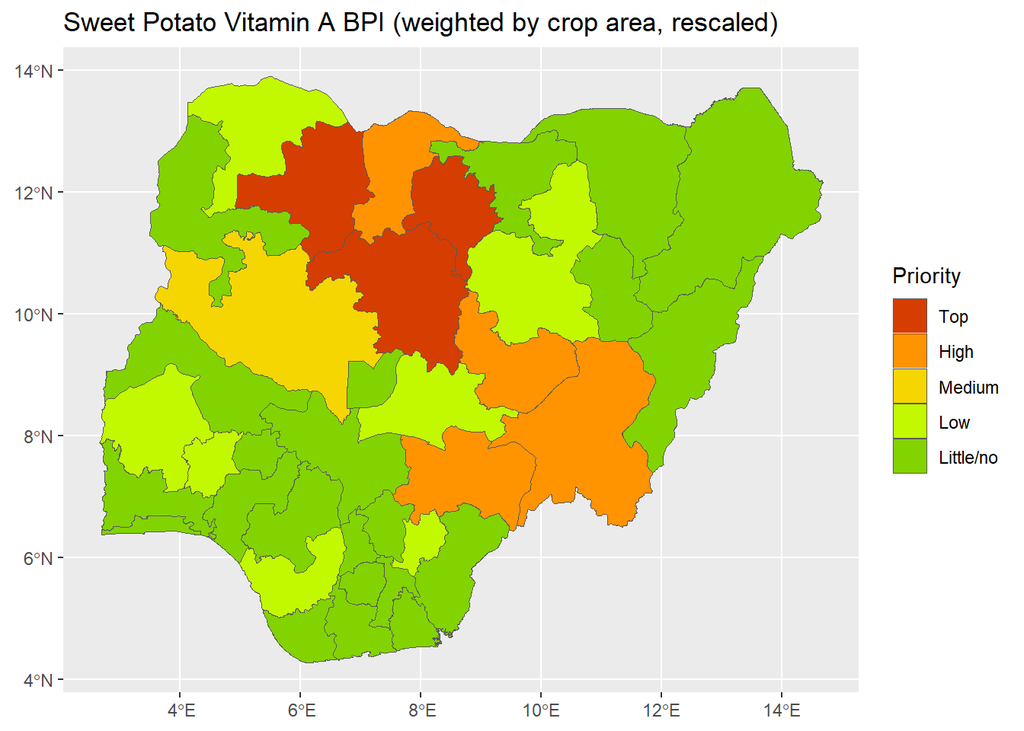

```r
df_spot_national_share <- read.csv("tab_data/spot_area_national_share_2022.csv")

df_spot_VitA_BPI_weighted <- left_join(df_spot_VitA_BPI_rescale, df_spot_national_share, by = "adm1_ref_name") |>
  mutate( spot_VitA_BPI_weight_share = (spot_VitA_BPI_rescale * spot_Area_2022_pc))

df_spot_VitA_BPI_weighted_normalised <- as.data.frame(lapply(select(df_spot_VitA_BPI_weighted, spot_VitA_BPI_weight_share ), minMax)) |>
  mutate(spot_VitA_BPI_weight_share_rescale = (spot_VitA_BPI_weight_share * 100))

df_spot_VitA_BPI_weighted_rescale <- bind_cols(select(df_spot_VitA_BPI_weighted, adm1_ref_name), df_spot_VitA_BPI_weighted_normalised)

vect_state_geo_spot_VitA_BPI_weighted_rescale <- dplyr::left_join(vect_state_geo, df_spot_VitA_BPI_weighted_rescale, by = "adm1_ref_name")

ggplot(vect_state_geo_spot_VitA_BPI_weighted_rescale) +
  geom_spatvector(aes(fill = spot_VitA_BPI_weight_share_rescale)) +
  scale_fill_stepsn(
    colors = colours_priority,
    values = scales::rescale(breaks_priority),
    breaks = breaks_priority,
    limits = c(0, 100),
    na.value = "grey",
    labels = labels_priority
  ) +
  guides(fill = guide_legend(reverse=T)) +
  labs(title = "Sweet Potato Vitamin A BPI (weighted by crop area, rescaled)", fill = "Priority") +
  theme(
    plot.title = element_markdown(),
    legend.title = element_markdown(),
    axis.title = element_blank()
  )
```

```r
df_pop_share <- read.csv("tab_data/BPI_target_pop_nbs.csv") |> select(state_name, pop_est_women_15_49_children_0_5_share_2025)
```

### Plantain/Banana Vitamin A BPI weighted by state share of target population

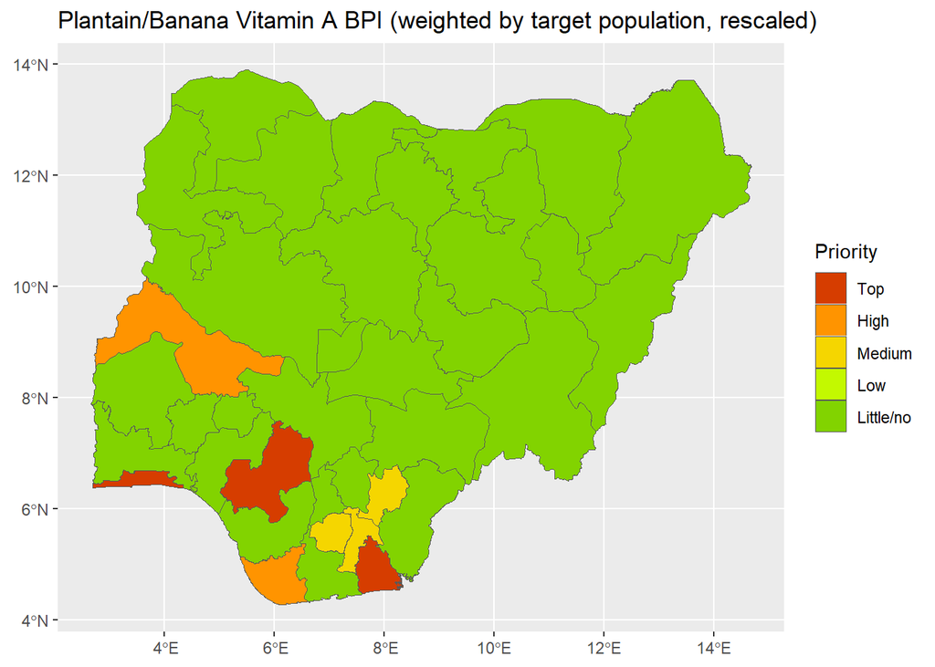

```r
df_plantain_banana_VitA_BPI_pop_weighted <- left_join(df_plantain_banana_VitA_BPI_rescale, df_pop_share, by = c("adm1_ref_name" = "state_name")) |>
  mutate( plantain_banana_VitA_BPI_pop_weight_share = (plantain_banana_VitA_BPI_rescale * pop_est_women_15_49_children_0_5_share_2025))

df_plantain_banana_VitA_BPI_pop_weighted_normalised <- as.data.frame(lapply(select(df_plantain_banana_VitA_BPI_pop_weighted, plantain_banana_VitA_BPI_pop_weight_share ), minMax)) |>
  mutate(plantain_banana_VitA_BPI_pop_weight_share_rescale = (plantain_banana_VitA_BPI_pop_weight_share * 100))

df_plantain_banana_VitA_BPI_pop_weighted_rescale <- bind_cols(select(df_plantain_banana_VitA_BPI_pop_weighted, adm1_ref_name), df_plantain_banana_VitA_BPI_pop_weighted_normalised)

vect_state_geo_plantain_banana_VitA_BPI_pop_weighted_rescale <- dplyr::left_join(vect_state_geo, df_plantain_banana_VitA_BPI_pop_weighted_rescale, by = "adm1_ref_name")

ggplot(vect_state_geo_plantain_banana_VitA_BPI_pop_weighted_rescale) +
  geom_spatvector(aes(fill = plantain_banana_VitA_BPI_pop_weight_share_rescale)) +
  scale_fill_stepsn(
    colors = colours_priority,
    values = scales::rescale(breaks_priority),
    breaks = breaks_priority,
    limits = c(0, 100),
    na.value = "grey",
    labels = labels_priority
  ) +
  guides(fill = guide_legend(reverse=T)) +
  labs(title = "Plantain/Banana Vitamin A BPI (weighted by target population, rescaled)", fill = "Priority") +
  theme(
    plot.title = element_markdown(),
    legend.title = element_markdown(),
    axis.title = element_blank()
  )
```

### Cassava Vitamin A BPI weighted by state share of target population

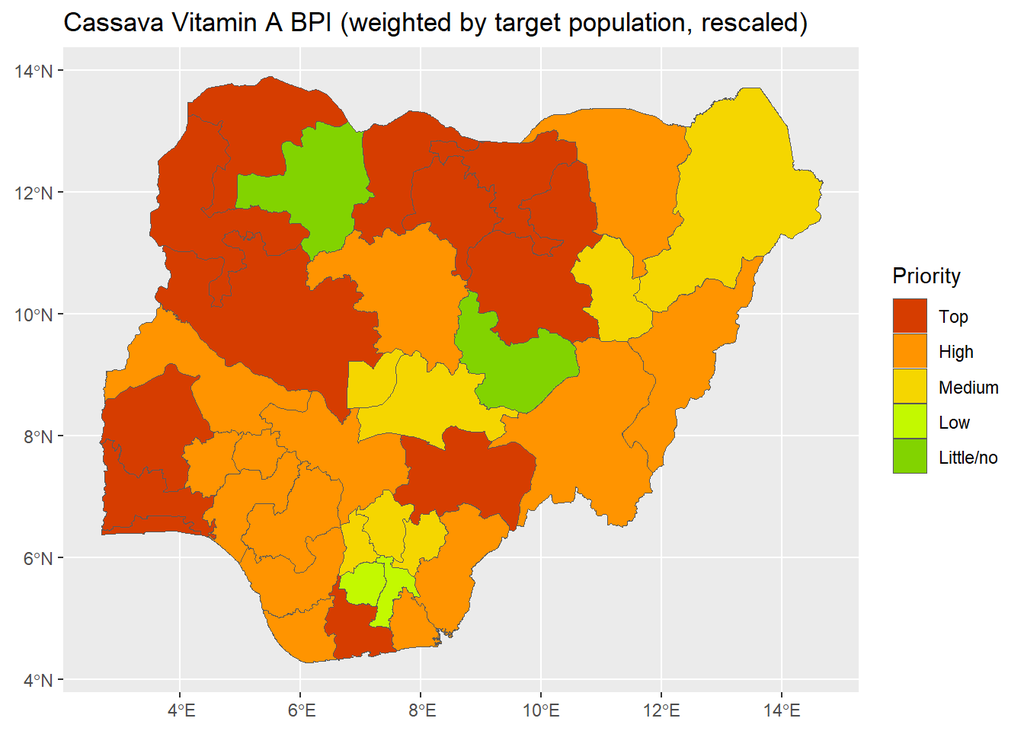

```r
df_cassava_VitA_BPI_pop_weighted <- left_join(df_cassava_VitA_BPI_rescale, df_pop_share, by = c("adm1_ref_name" = "state_name")) |>
  mutate( cassava_VitA_BPI_pop_weight_share = (cassava_VitA_BPI_rescale * pop_est_women_15_49_children_0_5_share_2025))

df_cassava_VitA_BPI_pop_weighted_normalised <- as.data.frame(lapply(select(df_cassava_VitA_BPI_pop_weighted, cassava_VitA_BPI_pop_weight_share ), minMax)) |>
  mutate(cassava_VitA_BPI_pop_weight_share_rescale = (cassava_VitA_BPI_pop_weight_share * 100))

df_cassava_VitA_BPI_pop_weighted_rescale <- bind_cols(select(df_cassava_VitA_BPI_pop_weighted, adm1_ref_name), df_cassava_VitA_BPI_pop_weighted_normalised)

vect_state_geo_cassava_VitA_BPI_pop_weighted_rescale <- dplyr::left_join(vect_state_geo, df_cassava_VitA_BPI_pop_weighted_rescale, by = "adm1_ref_name")

ggplot(vect_state_geo_cassava_VitA_BPI_pop_weighted_rescale) +
  geom_spatvector(aes(fill = cassava_VitA_BPI_pop_weight_share_rescale)) +
  scale_fill_stepsn(
    colors = colours_priority,
    values = scales::rescale(breaks_priority),
    breaks = breaks_priority,
    limits = c(0, 100),
    na.value = "grey",
    labels = labels_priority
  ) +
  guides(fill = guide_legend(reverse=T)) +
  labs(title = "Cassava Vitamin A BPI (weighted by target population, rescaled)", fill = "Priority") +
  theme(
    plot.title = element_markdown(),
    legend.title = element_markdown(),
    axis.title = element_blank()
  )
```